# Die Welt von R - Kapitel 1

# 1 Grundlagen

## 1.1 Die Benutzeroberfläche

Um mit R zu arbeiten, lade R und ggf. RStudio online kostenfrei herunter. Um R auszuführen, schreibe deinen Code in die Console unten links. Um es auszuführen drücke Enter. Oben links kannst du ein neues R Script öffnen und so als Editor nutzen. Um den geschriebenen Code in die Console zu schicken, setze den Cursor an das Ende der Zeile, die du schreiben willst und drücke in der Leiste darüber Run. Für alle Zeilen markiere diese und drücke Run.  
Führe jetzt deinen ersten Code aus, z.B. die Summe zweier Zahlen. Benutze R also als Taschenrechner.

```r
6 + 4
```

```
## [1] 10
```

Die Zeile beginnt mit dem erste Wert [1] deines Ergebnisses. Es gibt natürlich Befehle, die mehr als einen Wert ausgeben. So geben wir z.B. die Werte von 10 bis 13 wie folgt aus.

```r
10:13
```

```
## [1] 10 11 12 13
```

Die Ausgabe erfolgt. Die Zahlen in den eckigen Klammern sind also zu vernachlässigen, helfen aber natürlich. Du weißt aber wahrscheinlich schon was ein Index ist.  
Auch wissen wir jetzt schon wie man alle ganzen Zahlen zwischen zwei Zahlen widergibt. Hurra.

Auch über mehrere Zeilen können wir schreiben. Lücken zwischen den Zahlen und Operatoren sind dabei erlaubt.

```r
99 -
+
+ 98
```

```
## [1] 1
```

Fehlermeldungen sind nicht ungewöhnlich und auch nicht zu vermeiden. Lerne aus ihnen.  
Einfache arithmetische Rechnungen können wir schon intuitiv berechnen lassen. Hier gilt natürlich auch Punkt vor Strich. Komma müssen, falls notwendig, natürlich schon gesetzt werden. Der Code steht dabei in der Console immer nach dem >. Ohne lässt sich der Code aber einfacher kopieren.

```r
4 + 44
```

```
## [1] 48
```

```r
44 - 45
```

```
## [1] -1
```

```r
33 / (4   -    1)
```

```
## [1] 11
```

Kommentare kannst du nach einem Hastag # schreiben. Sehr sinnvoll und zu empfehlen. Danach wird der Code nicht interpretiert. Ergebnisse, die R ausgibt werden hier nach einem ## angegeben.

## 1.2 Objekte

Jetzt wollen wir aber natürlich nicht nur Werte ausgeben, sondern diese auch speichern. Willst du z.B. einen Vektor benutzen, speichern und dann wieder benutzen, erstelle ein R Objekt. Daten kannst du z.B. als Objekt a oder b abspeichern und dann jederzeit benutzen.

```r
a <- 5
a
```

```
## [1] 5
```

```r
a + 5
```

```
## [1] 10
```

Die Zahlen 1 bis 6 können auch in einem Objekt abgespeichert werden und dann natürlich auch aufgerufen werden.

```r
die <- 1:6
die
```

```
## [1] 1 2 3 4 5 6
```

Wenn du ein Objekt erstellst, erscheint es rechts oben im Fenster Environment. Alle in der aktuellen Sitzung erstellten Objekte sind also einzusehen. Sehr praktisch.  
Bei der Erstellung von Objekten ist auf den Namen zu achten. Viele, aber nicht alle Namen, sind erlaubt. Ein Name kann nicht beginnen mt ^, !, $, @, +, -, /, oder *. Auch auf Groß- und Kleinschreibung ist zu achten.

| gute Namen | Problemnamen |
| --- | --- |
| a | 1versuch |
| b | ^mean |
| Auto | $ |
| my_variable | 3rd |
| .heute | !nicht_gut |

Schon benutzte Namen werden ohne Nachfrage einfach überschrieben. Also aufpassen!

```r
my_zahl <-1
my_zahl
```

```
## [1] 1
```

```r
my_zahl <- 999
my_zahl
```

```
## [1] 999
```

Deine Objektnamen kannst du mithilfe von `ls` abrufen.

```r
ls()
```

```
## [1] "a"       "die"     "my_zahl"
```

Zahlen können wir manipulieren, aber auch unseren Vektor der Zahlen 1 bis 6. Und abspeichern natürlich nie vergessen.

```r
die - 6
```

```
## [1] -5 -4 -3 -2 -1  0
```

```r
die / 2
```

```
## [1] 0.5 1.0 1.5 2.0 2.5 3.0
```

```r
die * die
```

```
## [1]  1  4  9 16 25 36
```

```r
die_zwei <- die * die
```

Hierbei multiplizieren wir die Vektoren elementenweise. Also erstes Element von Vektor 1 wird mit dem ersten Element von Vektor 2 mutipliziert usw. Es geht natürlich auch anders. Aber dazu erst später mehr.  
Wir können aber auch zwei Vektoren unterschiedlicher Länge multiplzieren oder addieren. Hierbei wird dann der kürzere Vektor so lange wiederholt bis die Anzahl der Elemente beider gleich ist.

```r
1:2
```

```
## [1] 1 2
```

```r
1:4
```

```
## [1] 1 2 3 4
```

```r
die
```

```
## [1] 1 2 3 4 5 6
```

```r
die + 3:6
```

```
## Warning in die + 3:6: Länge des längeren Objektes
##       ist kein Vielfaches der Länge des kürzeren Objektes
```

```
## [1]  4  6  8 10  8 10
```

```r
die + 1:3
```

```
## [1] 2 4 6 5 7 9
```

Eine Warnung wird ausgegeben, wenn die Länge des längeren Objektes kein Vielfaches des kürzeren Objektes ist.

Inneres `%*%` und äußeres Produkt `%o%` ergeben natürlich zwei komplett verschiedene Ergebnisse.

```r
die %*% die
```

```
##      [,1]
## [1,]   91
```

```r
die %o% die
```

```
##      [,1] [,2] [,3] [,4] [,5] [,6]
## [1,]    1    2    3    4    5    6
## [2,]    2    4    6    8   10   12
## [3,]    3    6    9   12   15   18
## [4,]    4    8   12   16   20   24
## [5,]    5   10   15   20   25   30
## [6,]    6   12   18   24   30   36
```

## 1.3 Funktionen

R kommt mit einer Menge an Funktionen daher. Wir können z.B. mit Hilfe der `round` Funktion runden oder die Fakultät berechnen `factorial`. Eine Funktion anzuwenden ist sehr leicht. Schreibe einfach den Namen der Funktion und lasse dann die Daten folgen.

```r
round(3.14)
```

```
## [1] 3
```

```r
factorial(4)
```

```
## [1] 24
```

Die Daten in den Klammern werden *Argumente* genannt. Diese können rohe Daten sein, ein R Objekt oder sogar das Ergebnis einer anderen R Funktion. Dabei kämpft sich R von innen nach außen vor (letztes Beispiel).

```r
mean(1:8)
```

```
## [1] 4.5
```

```r
mean(die)
```

```
## [1] 3.5
```

```r
round(mean(die))
```

```
## [1] 4
```

Die Funktion `sample` gibt uns eine Zufallsstichprobe beliebiger Länge wider. Hierbei müssen wir zwei Argumente angeben.  
`sample` gibt uns `size`Elemente des Vektors wider.

```r
sample(x = 1:6, size = 3)
```

```
## [1] 5 6 4
```

Wir können so einen Würfelwurf simulieren, auch ohne Würfel.

```r
sample(x = die, size = 1)
```

```
## [1] 2
```

```r
sample(x = die, size = 1)
```

```
## [1] 6
```

```r
sample(x = die, size = 1)
```

```
## [1] 3
```

```r
sample(x = die, size = 1)
```

```
## [1] 1
```

Jeder Würfelwurf gibt uns ein zufälliges Ergebns wider.  
Du kannst soviele Argumente wie du willst und wie nötig sind einer Funktion übergeben, getrennt durch ein Komma natürlich. Oftmals wird das erste Argument in den Klammern nicht extra benannt, da es sich meist um die Daten handelt.

```r
sample(die, size = 2)
```

```
## [1] 1 6
```

```r
sample(die, size = 2)
```

```
## [1] 2 4
```

```r
sample(size = 2, x = die)
```

```
## [1] 4 3
```

Die Reihenfolge kann vertauscht werden. Es ist aber nicht zu empfehlen.  
Wenn du dir nicht sicher bist, welcher Name zu welcher Funktion passt, benutze den Befehl `args`. Er zeigt dir die benötigten Argumente der Funktion an.

```r
args(round)
```

```
## function (x, digits = 0)
## NULL
```

Hier siehst du auch, dass die Anzahl der Nachkommastellen auf 0 gesetz sind. Das is der *Default* Wert. Gibst du kein Argument für die Anzahl der Nachkommastellen hier an, so wird auf eine ganze Zahl gerundet.

```r
round(3.1415)
```

```
## [1] 3
```

```r
round(3.1415, digits = 2)
```

```
## [1] 3.14
```

Um den Code besser zu verstehen, schreibe einfach die Namen aus. Nicht für immer, aber am Anfang hilft es. Dann ist wie oben erfolgt auch die Reihenfolge der Argumente vertauschbar.

### 1.3.1 Sample (Replacement)

Wir wollen jetzt einen doppelten Würfelwurf simulieren, also einen Wurf mit 2 Würfeln. Probiere es aus.

```r
sample(die, size = 2)
```

```
## [1] 1 3
```

So oft wir wollen werden zwei Würfel geworfen. Was fällt auf?  
Als Default wird bei `sample` ohne Zurücklegen (Replacement) geworfen. Das ist kein echter Wurf mit zwei Würfeln!  
Wir müssen noch ein weiteres Argument hinzufügen: `replace = TRUE`.

```r
sample(die, size = 2, replace = TRUE)
```

```
## [1] 2 1
```

Ohne bzw. mit `replace = FALSE` erhalten wir niemals zweimal dieselbe Augenzahl.  
Die Augensumme lässt sich berechnen.

```r
dice <- sample(die, size = 2, replace = TRUE)
sum(dice)
```

```
## [1] 7
```

In `dice` ist jetzt das Ergebnis gespeichert. Egal wie oft wir den Befehl aufrufen. Es wird nicht neu gewürfelt. Das beruhigt.

## 1.4 Eigene Funktionen schreiben

Wir haben unseren Würfelwurf mit R Code geschrieben.

```r
die <- 1:6
dice <- sample(die, size = 2, replace = TRUE)
sum(dice)
```

```
## [1] 3
```

Bei jedem Würfelwurf können wir den Code also aufs neue verwenden und erhalten ein valides Ergebnis.  
Einfacher wäre es aber eine neue, eigene Funktion zu schreiben. Das machen wir jetzt.

Unsere Funktion soll `roll()` heißen, so dass immer ein Ergebnis zwischen 2 und 12 erscheint: die Augensumme.

### 1.4.1 Funktionen konstruieren

Jede Funktion in R besteht aus drei Teilen: Name, Body, Code.  
Diese drei Teile packen wir in ein R Objekt, welches mit der `function` Funktion erfolgt, gefolgt von geschweiften Klammern:  
`my_function <- function() {}`. In die geschweiften Klammern kommt der Body. Hier sagen wir R was es zu tun hat.

```r
roll <- function(){
  die <- 1:6
  dice <- sample(die, size = 2, replace = TRUE)
  summe_würfel <- sum(dice)
  return (summe_würfel)
}
```

`return` könnten wir hier auch weglassen und stattdessen bloß `summe_würfel` schreiben. Jetzt wird mit `return` die Augensumme der Würfel widergegeben. Der Output soll natürlich gespeichert werden. Nicht vergessen. Zum Aufrufen verwenden wir `roll()`. Die Klammern sind der Trigger, um die Funktion auszuführen. Ohne die Klammern wird bloß der Code ausgegeben.

```r
roll()
```

```
## [1] 9
```

```r
roll()
```

```
## [1] 7
```

```r
roll()
```

```
## [1] 11
```

```r
roll
```

```
## function(){
##   die <- 1:6
##   dice <- sample(die, size = 2, replace = TRUE)
##   summe_würfel <- sum(dice)
##   return (summe_würfel)
## }
## <bytecode: 0x000002aad33209a8>
```

R führt den ganzen Code im Body aus und gibt als Resultat die letzte Zeile Code wider. Überlege also was passiert, wenn du Zeile für Zeile des Bodys in die Command Zeile eingibst. Würde R ein Resultat nach der letzten Zeile ausgeben?

## 1.5 Argumente

Eine Fehlermeldung erhalten wir, da wir etwas vergessen haben und falschen Namen verwendet haben.

```r
roll2 <- function() {
  dice <- sample(bones, size = 2, replace = TRUE)
  sum(dice)
}
```

Die Funktion braucht das Objekt `bones`. Aber er wird hier nicht gefunden.  
`roll2()` erzeugt einen Fehler. Wir können aber `bones` verwenden, wenn wir `bones` zu einem Argument der Funktion machen. `bones` kommt also in die Klammern der Funktion.

```r
roll2 <- function(bones) {
  dice <- sample(bones, size = 2, replace = TRUE)
  sum(dice)
}
```

Jetzt funktioniert `roll2` solange `bones` in der Funktion aufgerufen wird. Dadurch sind wir auch deutlich flexibler, sodass unser Würfel nicht nur 6 Seiten haben muss, sondern beliebig viele.

```r
roll2(bones = 1:4)
```

```
## [1] 7
```

```r
roll2(bones = 1:6)
```

```
## [1] 9
```

```r
roll2(1:20)
```

```
## [1] 40
```

Gibst du keinen Wert für das Argument an, so erscheint eine Fehlermeldung. Um eine Fehlermeldung zu vermeiden, kannst du einen Defaultwert angeben.

```r
roll2 <- function(bones = 1:6) {
  dice <- sample(bones, size = 2, replace = TRUE)
  sum(dice)
}
```

Ein neuer Wert als Arument liefert gewünschte Ergebnisse. Wird er vergessen übernimmt der Defaultwert seinen Job.  
Du kannst deiner Funktion soviele Argumente wie du willst übergeben. Nenne diese und Liste sie durch Komma getrennt in den Klammern auf.  
Jeder Argumentname in der Funktion wird beim Laufen jetzt durch die gegebenen Werte ersetzt. Sind Defaultwerte gegeben, so liefern diese bei Nichtnennung eigener Werte, die Daten für die Funktion.

Baue dir also eigene Funktionen! Einmal konstruiert behandelt R deine Funktion wie jede andere Funktion in R, z.B. mean, round, max, etc. Und denke daran. Die Funktion gibt das Ergebnis der letzten Zeile des Body aus. Die Zeile vor der schließenden geschweiften Klammer.

# 2 Pakete und Hilfspakete

Wir haben einen Würfelwurf kostruiert und können jetzt überprüfen, ob dieser faire Ergebnisse liefert. Zwei Werkzeuge helfen uns dabei: Wiederholung und Visualisierung. Wir werden unsere Würfelwürfe wiederholen und anschaulich visualisieren. Hierzu brauchen wir Pakete, die uns dabei helfen. Sie sind noch nicht in unserem Download enthalten. Viele der mächtigsten Werkzeuge sind in R Paketen enthalten. Lass uns schauen was R Pakete sind und wie wir sie benutzen können.

## 2.1 Pakete

Wir sind nicht die einzigen Personen, die in R Funktionen schreiben. Viele schlaue Köpfe benutzen R und entwickeln Werkzeuge, die uns bei der Datenanalyse helfen können.  
Sie werden kostenfrei bereitgestellt, nur anwenden müssen wir sie noch selber. Sie kommen als vormontierte Sammlung von Funktionen und Objekte: Pakete.

Um ein paar schnelle Plots zu erhalten benutzen wir die `qplot` Funktion im *ggplot2* Paket. Zuvor muss es gedownloaded und installiert werden.

### 2.1.1 install.packages

Jedes R Paket ist zu finden auf [link](http://cran.r-project.org). Herunterladen können wir es über die Command line durch: `install.packages("ggplot2")`.

### 2.1.2 library

Mit dem Befehl `library("ggplot2")` können wir es zugänglich machen. Ersetze ggplot2 natürlich beliebig.

`qplot` erstellt schnelle Plots. Zwei Vektoren der selben Länge und schon haben wir einen Scatterplot erstellt. Hierbei wird ein Vektor mithilfe der `c` Funktion erstellt. In den Klammern getrennt durch Komma stehen die einzelnen Werte.

```r
library(ggplot2)
x <- c(12,14,16,17,12,13,14,10,-5,-2)
y <- x^2
y
```

```
##  [1] 144 196 256 289 144 169 196 100  25   4
```

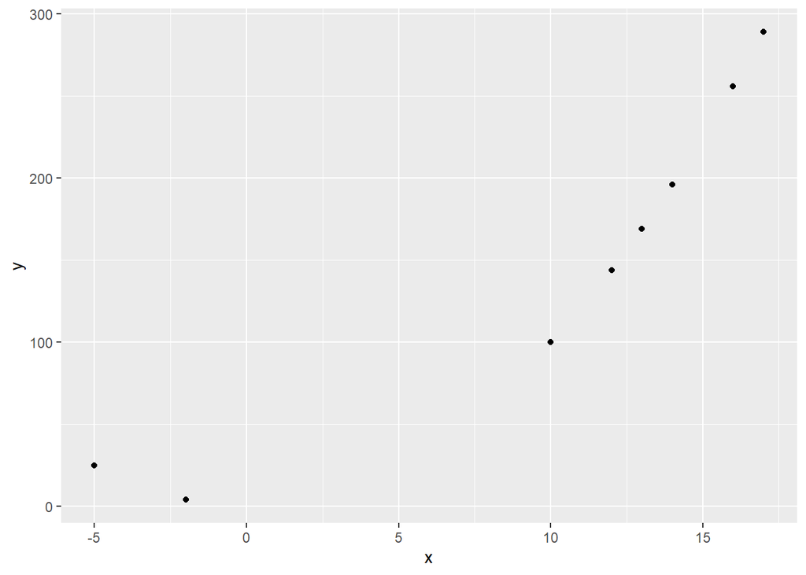

```r
qplot(x,y)
```

Elementenweise werden die Punktepaare erzeugt. Übergeben wir `qplot` nur einen Vektor, erzeugt R ein Histogramm.

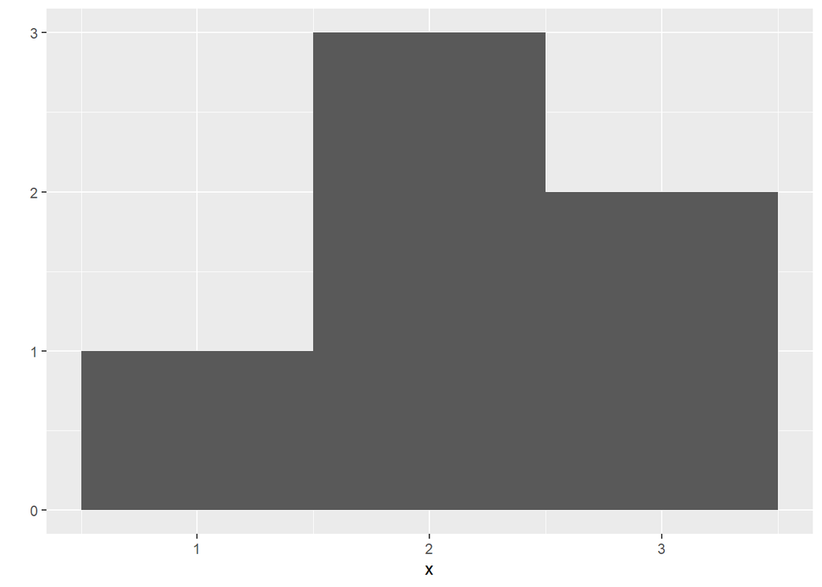

```r
x <- c(1,2,2,2,3,3)
qplot(x, binwidth = 1)
```

Unsere Intervalle gehen jeweils +- 0.5, da die Bandbreite (binwidth) = 1 ist.

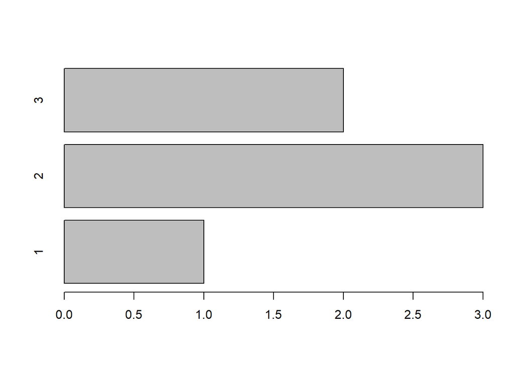

```r
x <- c(1,2,2,2,3,3)
barplot(table(x), horiz = TRUE)
```

Ein wenig anschaulicher ist ein Barplot.  
Kommen wir auf unser Würfelexperiment zurück. Wollen wir den Würfelwurf, den wir simuliert haben, beliebig oft wiederholen, können wir die mit `replicate` tun. Zuerst steht in der Klammer die Anzahl der Wiederholungen, dann was wiederholt werden soll. In unserem Fall der zweimalige Würfelwurf mit Zurücklegen. Die Summe ergibt Zahlen zwischen 2 und 12.

```r
replicate(5, 2)
```

```
## [1] 2 2 2 2 2
```

```r
replicate(10, roll())
```

```
##  [1] 9 3 8 2 7 9 3 6 7 4
```

Jetzt können wir die beiden Würfel aber auch 10 000 mal werfen und die Augensumme notieren. Also simulieren wir mal. Welche Grafik ist wohl sinnvoller?

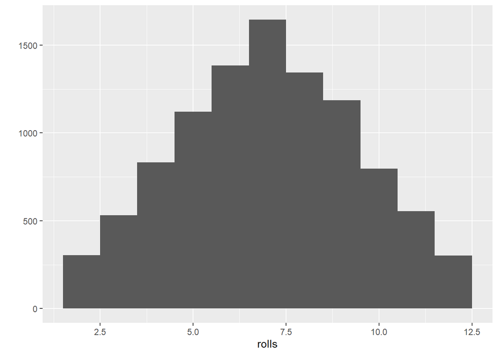

```r
rolls <- replicate(10000, roll())
qplot(rolls, binwidth = 1)
```

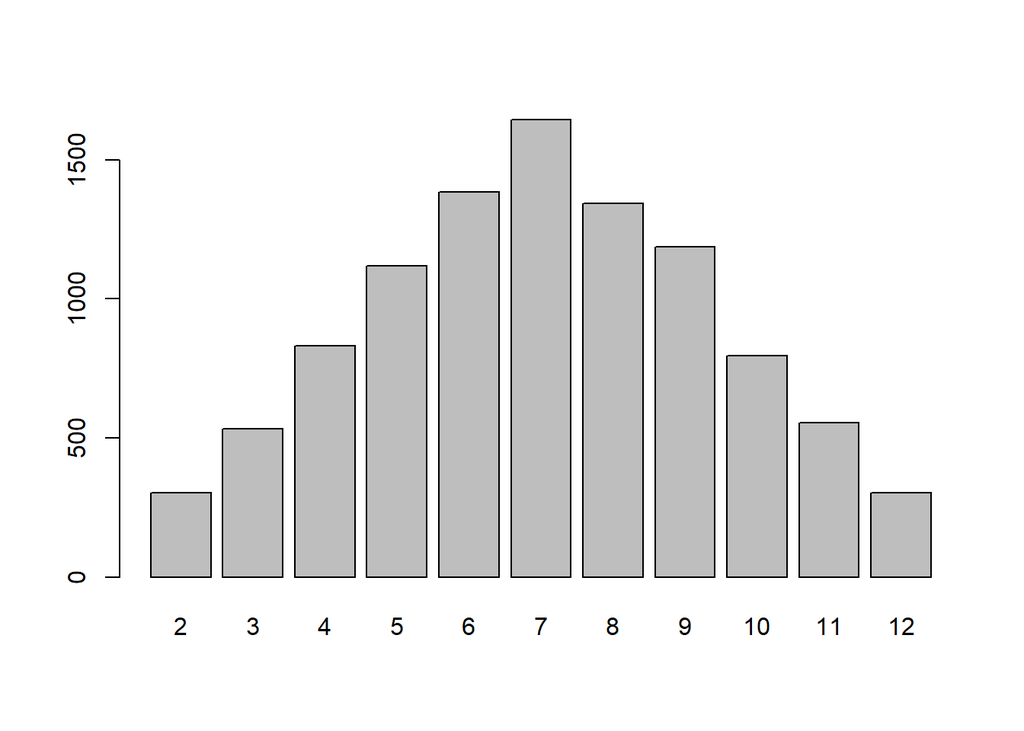

```r
barplot(table(rolls), horiz = F)
```

Es sieht alles nach einem fairen Würfel aus. Um ihn unfair zu machen könnten wir die Wahrscheinlichkeiten ändern:

| Zahl | faire WKT | gewichtete WKT |
| --- | --- | --- |
| 1 | 1/6 | 1/8 |
| 2 | 1/6 | 1/8 |
| 3 | 1/6 | 1/8 |
| 4 | 1/6 | 1/8 |
| 5 | 1/6 | 1/8 |
| 6 | 1/6 | 3/8 |

Die Wahrscheinlichkeiten können wir ändern, indem wir der `sample` Funktion ein Argument hinzufügen. Mache dies mithilfe der “Hilfeseite”.

## 2.2 Hilfe suchen mit Hilfeseiten

Hilfeseiten können über ein Fragezeichen vor der Funktion aufgerufen werden: `?sqrt`, `?log10` und `?sample` sind Beispiele. Sie enthalten Informationen über das, was jede Funktion macht. Am Ende von ihnen findet man meist anschauliche Beispiele.  
Kommt die Funktion in einem R Paket daher, muss dieses natürlich zuvor geladen werden.

### 2.2.1 Abschnitte der Hilfeseiten

Folgende Themen sind meist zu finden:

**Beschreibung** Eine Beschreibung was die Funktion macht.

**Usage** Ein Beispiel wie du die Funktion schreiben würdest.

**Argumente** Eine Liste der Argumente. Welche Art von Argumenten erwartet R und was macht die Funktion mit den Informationen.

**Details** Eine tiefere Beschreibung der Funktion.

**Value** Was gibt die Funktion dir wider?

**See Also** Verwandte R Funktionen.

**Examples** Beispiele.

Hast du die Funktion vergessen bzw. den Namen, gib zwei Fragezeichen und dann das Keywort an. Es ist eine Hilfeseite für eine Hilfeseite (z.B. `??log`).

Wir rufen also `?sample` auf. Hier stehen viele wichtige Infos, die wir zum bauen unserer Funktion brauchen. `sample(x, size, replace = FALSE, prob = NULL)`.  
Unsere `roll()` Funktion rufen wir uns in Erinnerung.

```r
roll <- function() {
  die <- 1:6
  dice <- sample(die, size = 2, replace = TRUE)
  sum(dice)
}
```

Um unsere Wahrscheinlichkeiten anzupassen, fügen wir ein weiteres Argument hinzu: `prob` mit einem Vektor von Gewichten.

```r
roll <- function() {
  die <- 1:6
  dice <- sample(die, size = 2, replace = T,
     prob = c(1/8, 1/8, 1/8, 1/8, 1/8, 3/8))
  sum(dice)
}
roll()
```

```
## [1] 7
```

Wir überschreiben unsere Ergebnisse.

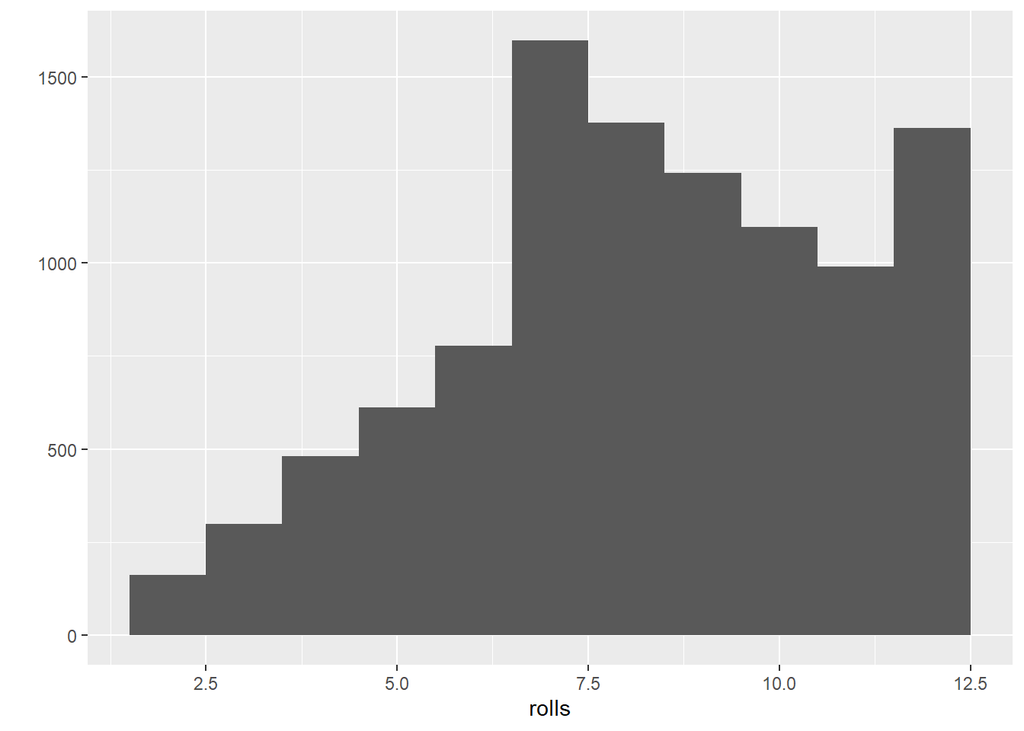

```r
rolls <- replicate(10000, roll())
qplot(rolls, binwidth = 1)
```

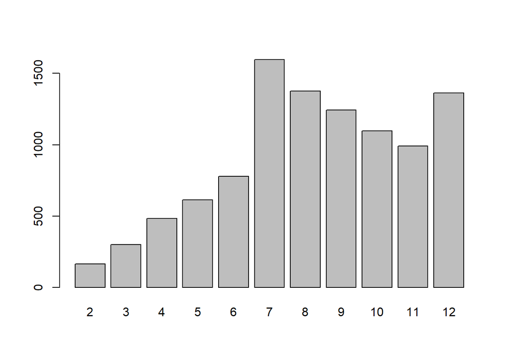

```r
barplot(table(rolls), horiz = F)
```

### 2.2.2 Noch mehr Hilfe

Stack Overflow  
Google  
RStudio link

# 3 R Objekte

## 3.1 Vektoren

Ein Vektor ist schnell gebildet aus ein paar Werten und einem `c`.

```r
die <- c(1,2,3,4,5,6)
die
```

```
## [1] 1 2 3 4 5 6
```

```r
is.vector(die)
```

```
## [1] TRUE
```

Wir erstellen einen Vektor und überprüfen, ob es wirklich einer ist. Die möglichen Ergebnisse sind natürlich TRUE oder FALSE. Auch aus einem Wert ist ein Vektor zu bilden. Mit der Länge 1 natürlich.

```r
five <- 5
is.vector(five)
```

```
## [1] TRUE
```

```r
length(five)
```

```
## [1] 1
```

```r
length(die)
```

```
## [1] 6
```

Ein eindimensionaler Vektor kann nur einen Datentyp beinhalten. Insgesamt gibt es sechs verschiedene Typen von Vektoren:  
doubles  
integers  
characters  
logicals  
complex  
raw.

Wir wollen jetzt ein 52er Kartendeck erstellen. Dafür brauchen wir natürlich verschiedene Datentypen (Text und Zahlen). Bei der Dateneingabe werden sie durch gewisse Konventionen angegeben. Bei der Dateneingabe kann ein `L` mit angegeben werden für integer und Anführungszeichen für character.

```r
int <- 1L
text <- "ace"
```

Vektoren mit mehr als einem Element können natürlich auch erstellt werden.

```r
int <- c(1L, 5L)
text <- c("ace", "hearts")
```

Verschiedene Typen sind notwendig, da sie auf Funktionen verschiedenartig reagieren.

```r
sum(int)
```

```
## [1] 6
```

```r
# sum(text) Fehlermeldung
```

### 3.1.1 Doubles

Ein double Vektor enthält reguläre Zahlen: positive Zahlen, negative Zahlen, große oder kleine, Zahlen mit oder ohne Nachkommastellen.  
R speichert jede Zahl, die du eintippst, als double ab. Abfragen kannst du diesen Typ leicht mit `typeof`.

```r
die <- c(1,2,3,4,5,6)
die
```

```
## [1] 1 2 3 4 5 6
```

```r
typeof(die)
```

```
## [1] "double"
```

Einige R Funktionen deklarieren doubles als “numerics”.

### 3.1.2 Integers

Da du Integers als doubles abspeichern kannst, benutzt du diesen Datentypen nicht sehr oft. Erst folgt eine ganze Zahl, dann ein `L`.

```r
int <- c(-1L, 2L, 4L)
int
```

```
## [1] -1  2  4
```

```r
typeof(int)
```

```
## [1] "integer"
```

R speichert eine Zahl nur mit einem `L` so ab, ansonsten als doubles.

### 3.1.3 Characters

Hier wird Text abgespeichert. In Anführungszeichen.

```r
text <- c("Hello", "World")
text
```

```
## [1] "Hello" "World"
```

```r
typeof(text)
```

```
## [1] "character"
```

```r
typeof("Hello")
```

```
## [1] "character"
```

Die individuellen Elemente eines Character Vektors sind als *strings* bekannt. Ein String kann mehr als nur Buchstaben enthalten! Auch `"1"` ist ein Character string.

### 3.1.4 Logicals

Diese Vekoren beinhalten `TRUE` oder `FALSE`. Auch die Abkürzungen sind möglich: `T` oder `F`. Sie sind wichtig!

```r
3 > 4
```

```
## [1] FALSE
```

Jedes mal, wenn du `TRUE` oder `FALSE` in großen Buchstaben in R eingibst, wird es als logischer Wert wahrgenommen.

```r
logic <- c(TRUE, TRUE, TRUE)
logic
```

```
## [1] TRUE TRUE TRUE
```

```r
typeof(logic)
```

```
## [1] "logical"
```

```r
typeof(F)
```

```
## [1] "logical"
```

`T` und `F` können auch als Zahlen wahgenommen werden: 1 und 0. Dazu später mehr.

### 3.1.5 Complex und Raw

Bei der Datenanalyse werden sie selten gebraucht. Complex Vektors beihalten komplexe Zahlen. Um so einen Vektor zu erzeugen, füge einen imaginären Term zu einer Zahl mit `i`.

```r
comp <- c(1 + 1i, 1 + 2i,1 + 3i)
comp
```

```
## [1] 1+1i 1+2i 1+3i
```

```r
typeof(comp)
```

```
## [1] "complex"
```

Raw Vektoren beinhalten Datenbytes.

```r
raw(3)
```

```
## [1] 00 00 00
```

```r
typeof(raw(3))
```

```
## [1] "raw"
```

**Beispiel** für einen Character Vektor. Karten: Ein Royal Flush hat welche 5 Symbole auf den Karten?

```r
hand <- c("Ass", "König", "Dame", "Bube", "Zehn")
hand
```

```
## [1] "Ass"   "König" "Dame"  "Bube"  "Zehn"
```

```r
typeof(hand)
```

```
## [1] "character"
```

## 3.2 Attribute

Ein Atribut ist eine Zusatzinformation, die du an einen Vektor anhängen kannst. Es beeinflusst weder den Wert noch wird es angezeigt, wenn du dein Objekt ausgibst. Es ist vergleichbar mit “Metadaten”. R ignoriert normalerweise diese Metadaten, sie können aber durch Funktionen angezeigt werden. Über `attributes` kannst du dir diese anzeigen lassen. Hat ein Objekt kein Attribut, so wird `NULL` ausgegeben.

```r
attributes(die)
```

[output not shown]

### 3.2.1 Namen

Die populärsten Attribute eines Vektors sind Namen, Dimensionen und Klassen.  
Du kannst mit speziellen Funktionen dir dieses Attribut ausgeben lassen. Zum Beispiel kannst du nach dem Namen fragen mit `names`.

```r
names(die)
```

[output not shown]

`NULL` heißt, dass es kein names Attribut für `die` gibt. Das kannst du selbst zuordnen. Der Vektor enthält einen Namen für jedes Element in `die`.

```r
names(die) <- c("one", "two", "three", "four", "five", "six")
names(die)
```

```
## [1] "one"   "two"   "three" "four"  "five"  "six"
```

```r
attributes(die)
```

```
## $names
## [1] "one"   "two"   "three" "four"  "five"  "six"
```

```r
die
```

```
##   one   two three  four  five   six
##     1     2     3     4     5     6
```

```r
die + 1
```

```
##   one   two three  four  five   six
##     2     3     4     5     6     7
```

Die Namen affektieren nicht die aktuellen Werte, auch nicht bei Manipulation der Werte. Das Attribut kannst du natürlich auch wieder ändern.

```r
names(die) <- c("uno", "dos", "tres", "quatro", "cinco", "seis")
die
```

```
##    uno    dos   tres quatro  cinco   seis
##      1      2      3      4      5      6
```

Das Namensattribut kann auch ganz entfernt werden.

```r
names(die) <- NULL
die
```

```
## [1] 1 2 3 4 5 6
```

### 3.2.2 Dimension

Ein Vektor kann in einen n-dimensionalen Array transformiert werden, indem man ihm die Dimensinsattribute mit `dim` zuweist. So kannst du einen Vektor der Länge 6 in eine $2\times3$ - Matrix umwandeln mit zwei Zeilen und drei Spalten.

```r
dim(die) <- c(2, 3)
die
```

```
##      [,1] [,2] [,3]
## [1,]    1    3    5
## [2,]    2    4    6
```

```r
dim(die) <- c(3, 2)
die
```

```
##      [,1] [,2]
## [1,]    1    4
## [2,]    2    5
## [3,]    3    6
```

R füllt die Matrizen spaltenweise. Um diesen Prozess zu beeinflussen, schau in die Hilfsfunktionen `matrix` oder `array`.

## 3.3 Matrizen

Matrizen enthalten Werte in einem 2-dimensionalen Array. Nach `matrix` folgt in den Klammern der Datensatz, dann die Anzahl der Zeilen `nrow` oder die Anahl der Spalten `ncol`.

```r
m <- matrix(die, nrow = 2)
m
```

```
##      [,1] [,2] [,3]
## [1,]    1    3    5
## [2,]    2    4    6
```

`matrix` füllt die Matrix Spalte für Spalte (default). Du kannst sie aber reihenweise befüllen lassen mit dem Argument `byrow = T`.

```r
m <- matrix(die, nrow = 2, byrow = TRUE)
m
```

```
##      [,1] [,2] [,3]
## [1,]    1    2    3
## [2,]    4    5    6
```

## 3.4 Arrays

Die `array` Funktion erzeugt einen n-dimensionalen Array. Es wird nach einem Vektor als erstes Argument gefragt, dann folgt ein Vektor der Dimensionen `dim`.

```r
ar <- array(c(11:14, 21:24, 31:34), dim = c(2, 2, 3))
ar
```

```
## , , 1
##
##      [,1] [,2]
## [1,]   11   13
## [2,]   12   14
##
## , , 2
##
##      [,1] [,2]
## [1,]   21   23
## [2,]   22   24
##
## , , 3
##
##      [,1] [,2]
## [1,]   31   33
## [2,]   32   34
```

Bilde z.B. eine Matrix mit den Namen und Farbe eines Royal Flush.

```r
hand1 <- c("ace", "king", "queen", "jack", "ten", "spades", "spades", "spades", "spades", "spades")
matrix(hand1, nrow = 5)
```

```
##      [,1]    [,2]
## [1,] "ace"   "spades"
## [2,] "king"  "spades"
## [3,] "queen" "spades"
## [4,] "jack"  "spades"
## [5,] "ten"   "spades"
```

```r
matrix(hand1, ncol = 2)
```

```
##      [,1]    [,2]
## [1,] "ace"   "spades"
## [2,] "king"  "spades"
## [3,] "queen" "spades"
## [4,] "jack"  "spades"
## [5,] "ten"   "spades"
```

```r
dim(hand1) <- c(5, 2)
hand1
```

```
##      [,1]    [,2]
## [1,] "ace"   "spades"
## [2,] "king"  "spades"
## [3,] "queen" "spades"
## [4,] "jack"  "spades"
## [5,] "ten"   "spades"
```

Auch kannst du Zeilenweise einlesen aus:

```r
hand2 <- c("ace", "spades", "king", "spades", "queen", "spades", "jack", "spades", "ten", "spades")
matrix(hand2, ncol = 2, byrow = T)
```

```
##      [,1]    [,2]
## [1,] "ace"   "spades"
## [2,] "king"  "spades"
## [3,] "queen" "spades"
## [4,] "jack"  "spades"
## [5,] "ten"   "spades"
```

## 3.5 Klassen

Änderst du die Dimension deines Objektes, so ändert sich nicht der Typ des Objektes, aber seine Klasse.

```r
dim(die) <- c(2, 3)
die
```

```
##      [,1] [,2] [,3]
## [1,]    1    3    5
## [2,]    2    4    6
```

```r
typeof(die)
```

```
## [1] "double"
```

```r
class(die)
```

```
## [1] "matrix" "array"
```

Jedes Element der Matrix ist immer noch ein double, aber es hat eine neue Struktur angenommen. R hat ein `class` Attribut hinzugefügt, nachdem du seine Dimension geändert hast.  
Viele Funktionen suchen nach einem bestimmten `class` Attribut, um dann gemäß seiner Eigenschaft sich zu verhalten. Die Klasse von einem double ist numerisch, von einem String “character”.

### 3.5.1 Datum und Zeit

Die Zeit sieht wie ein Character String aus, ist aber normalerweise ein `"double"` und seine Klasse ist `"POSIXct"` `"POSIXT"`.

```r
now <- Sys.time()
now
```

```
## [1] "2023-08-25 04:17:04 CEST"
```

```r
typeof(now)
```

```
## [1] "double"
```

```r
class(now)
```

```
## [1] "POSIXct" "POSIXt"
```

Jede Zeit wird im POSIXct Framework durch Sekunden nach dem 1.1.1970, 0 Uhr dargestellt. R stellt das Zeitobjekt als double mit einem Element dar.

```r
unclass(now) # Sekunden seit dem 1.1.1970
```

```
## [1] 1692929825
```

### 3.5.2 Faktoren

Mit Faktoren kann R kategorielle Informationen wie z.B. Augenfarbe oder ethnische Zugehörigkeit, abspeichern. Ein Faktor kann nur eine bestimmte Anzahl an Werten annehmen (z.B. m/w als Geschlecht) und diese Werte haben ihre eigene Anordnung.  
Kategorische Variablen sind hier also zuhause. Um einen Faktor anzuwenden, stecke einen Vektor in die `factor` Funktion. R recodiert die Daten in dem Vektor als Integers. R fügt auch noch ein `levels` Attribut hinzu, welches ein Set von Labels für die Darstellung der Faktorwerte enthält. Außerdem noch ein `class` Attribut, welches die Klasse `factor` enthält. R ordnet deinen Faktor mit `unclass`.

```r
gender <- factor(c("male", "femle", "female", "male"))
typeof(gender)
```

```
## [1] "integer"
```

```r
attributes(gender)
```

```
## $levels
## [1] "female" "femle"  "male"
##
## $class
## [1] "factor"
```

```r
unclass(gender)
```

```
## [1] 3 2 1 3
## attr(,"levels")
## [1] "female" "femle"  "male"
```

```r
gender
```

```
## [1] male   femle  female male
## Levels: female femle male
```

```r
as.character(gender)
```

```
## [1] "male"   "femle"  "female" "male"
```

**Beispiel** Kartenspiel.  
Manche Kartenspiele ordnen einer Karte einen numerischen Wert zu, wie z.B. Blackjack. Wir kombinieren jetzt Ass, Herz und 1 in einem Vektor. Welcher Typ eines Vektors entsteht jetzt? *Lösung* Diese Übung geht nicht klar. Jeder Vektor kann nur einen Datentypen annehmen. R zwingt all deine Werte zu einem Character String.

```r
card <- c("Ass", "Herz", 1)
card
```

```
## [1] "Ass"  "Herz" "1"
```

Jetzt wird das berechnen von Punkten mit Mathematik schwierig. Multiple Datentypen werden zu einem Datentypen zusammengefasst.

## 3.6 Coercion

Ist ein Character String in einem Vector vorhanden, so zwingt R alle anderen Elemente ebenfalls in einen Character String. Sind Zahlen und boolsche Werte (T und F) vorhanden, so konvertiert R diese zu Zahlen. `TRUE` wird zu 1 und `FALSE` wird zu 0.  
So kannst du leicht mathematische Operatoren auf Boolsche Werte anwenden.

```r
sum(c(TRUE, TRUE, FALSE, FALSE))
```

```
## [1] 2
```

```r
sum(c(T, T, F, F))
```

```
## [1] 2
```

```r
sum(c(1, 1, 0, 0))
```

```
## [1] 2
```

`sum` zählt also die Anzahl von `TRUE` in einem logical Vektor.  
Mit der `as` Funktion kanst du R zwingen Daten zu konvertieren. Natürlich nur, wenn es Sinn macht.

```r
as.character(1)
```

```
## [1] "1"
```

```r
as.logical(1)
```

```
## [1] TRUE
```

```r
as.numeric(FALSE)
```

```
## [1] 0
```

Es gibt aber einen Weg Coercion zu vermeiden. Nicht immer wollen wir nämlich Daten zwingen einen anderen Datentypen anzunehmen. Listen helfen hier. Vektoren, Matrizen und Arrays helfen hier nicht mehr.

## 3.7 Listen

Listen sind Vektoren nicht unähnlich. Sie stecken Daten in eine eindimensionale Reihe. Sie gruppieren allerdings nicht individuelle Werte, sondern R Objekte wie Vektoren und andere Listen.  
Zum Beispiel kannst du eine Liste erstellen aus einem numerischen Vektor der Länge 31 als erstes Element, einem Character Vektor der Länge 1 als zweites Element und einer neuen Liste der Länge 2.

```r
list1 <- list(100:130, "R", list(TRUE, FALSE))
list1
```

```
## [[1]]
##  [1] 100 101 102 103 104 105 106 107 108 109 110 111 112 113 114 115 116 117 118
## [20] 119 120 121 122 123 124 125 126 127 128 129 130
##
## [[2]]
## [1] "R"
##
## [[3]]
## [[3]][[1]]
## [1] TRUE
##
## [[3]][[2]]
## [1] FALSE
```

`100` ist das erste Unterelement des ersten Element. `"R"` das erste Unterelement des zweiten Elements.  
Die Struktur von Listen kann sehr kompliziert und lang werden. Aber die Flexibilität macht Listen zu einem sehr nützlichen Ablageort für verschiedenste Daten und Informaionen. Mit Listen kannst du alles zusammen lagern.

**Beispiel** Liste für Kartenbeispiel.

Eine Spielkarte mit Wert können wir so leicht speichern. Aus Character Vektor, Character Vektor und numerischem Vektor. Alle mit Länge 1.

```r
card <- list("ace", "hearts", 1)
card
```

```
## [[1]]
## [1] "ace"
##
## [[2]]
## [1] "hearts"
##
## [[3]]
## [1] 1
```

Ein ganzes Deck Karten lannst du auch so speichern. Als Liste mit Unter-/Sublisten. Du kannst aber einfach eine spezielle Klasse von Listen benutzen. Einen Data Frame.

## 3.8 Data Frames

Data Frames sind die 2-dimensionale Version von Listen. Sie speichern Daten ähnlich wie Excel in einer 2-dim Tabelle. Aus Vektoren werden Spalten, so dass jede Spalte aus einem anderen Datentyp bestehen kann. Innerhalb der Spalte natürlich nicht.

| numeric | character | logical |
| --- | --- | --- |
| 1 | “R” | TRUE |
| 2 | “ist” | TRUE |
| 3 | “doch” | TRUE |
| 4 | “eigentlich” | FALSE |
| 5 | “ganz” | FALSE |
| 6 | “cool” | TRUE |

Die Spalten müssen natürlich alle gleich lang sein.

```r
df <- data.frame(Kartenwert = c("ass", "zwei", "sechs"), Farbe = c("kreuz", "kreuz", "kreuz"), Zahlenwert = c(1, 2, 6))
df
```

```
##   Kartenwert Farbe Zahlenwert
## 1        ass kreuz          1
## 2       zwei kreuz          2
## 3      sechs kreuz          6
```

Die Spalten kannst du natürlich beliebig benennen.  
Der Typ (type) eines Data Frames ist eine Liste. Du kannst sehen aus welchen Typen der Objekte die Liste/Data Frame zusammen gesetzt wurde, mithilfe der `str` Funktion.

```r
typeof(df)
```

```
## [1] "list"
```

```r
class(df)
```

```
## [1] "data.frame"
```

```r
str(df)
```

```
## 'data.frame':    3 obs. of  3 variables:
##  $ Kartenwert: chr  "ass" "zwei" "sechs"
##  $ Farbe     : chr  "kreuz" "kreuz" "kreuz"
##  $ Zahlenwert: num  1 2 6
```

```r
df <- data.frame(Kartenwert = c("ass", "zwei", "sechs"), Farbe = c("kreuz", "kreuz", "kreuz"), Kartenzahl = c(1, 2, 6), stringsAsFactors = FALSE)
```

Unser Kartendeck kann jetzt also gebaut werden. Zeilen sind die Karten. Spalten sind die Typen der Werte: 52 Zeilen und 3 Spalten haben wir. Auf englisch komplett.

```r
deck <- data.frame(
  face = c("king", "queen", "jack", "ten", "nine", "eight", "seven", "six",
    "five", "four", "three", "two", "ace", "king", "queen", "jack", "ten",
    "nine", "eight", "seven", "six", "five", "four", "three", "two", "ace",
    "king", "queen", "jack", "ten", "nine", "eight", "seven", "six", "five",
    "four", "three", "two", "ace", "king", "queen", "jack", "ten", "nine",
    "eight", "seven", "six", "five", "four", "three", "two", "ace"),
  suit = c("spades", "spades", "spades", "spades", "spades", "spades",
    "spades", "spades", "spades", "spades", "spades", "spades", "spades",
    "clubs", "clubs", "clubs", "clubs", "clubs", "clubs", "clubs", "clubs",
    "clubs", "clubs", "clubs", "clubs", "clubs", "diamonds", "diamonds",
    "diamonds", "diamonds", "diamonds", "diamonds", "diamonds", "diamonds",
    "diamonds", "diamonds", "diamonds", "diamonds", "diamonds", "hearts",
    "hearts", "hearts", "hearts", "hearts", "hearts", "hearts", "hearts",
    "hearts", "hearts", "hearts", "hearts", "hearts"),
  value = c(13, 12, 11, 10, 9, 8, 7, 6, 5, 4, 3, 2, 1, 13, 12, 11, 10, 9, 8,
    7, 6, 5, 4, 3, 2, 1, 13, 12, 11, 10, 9, 8, 7, 6, 5, 4, 3, 2, 1, 13, 12, 11,
    10, 9, 8, 7, 6, 5, 4, 3, 2, 1)
)
deck
```

```
##     face     suit value
## 1   king   spades    13
## 2  queen   spades    12
## 3   jack   spades    11
## 4    ten   spades    10
## 5   nine   spades     9
## 6  eight   spades     8
## 7  seven   spades     7
## 8    six   spades     6
## 9   five   spades     5
## 10  four   spades     4
## 11 three   spades     3
## 12   two   spades     2
## 13   ace   spades     1
## 14  king    clubs    13
```

[output cut: 38 more lines]

Lange Tipparbeit ist zu vermeiden, wenn möglich durch Einlesen von Daten.

## 3.9 Daten laden

Rechts oben im Fenster unter Environment kannst du Daten aus verschiedenen Quellen einlesen. “From text” und dann die .csv einlesen oder direkt unter `read.csv`. Dann folgt unter “…” die Quelle. Unter `head(deck)` kannst du dir dann die ersten Zeilen ausgeben lassen. Die bekannten Hilfeseiten helfen auch hier weiter, falls es Probleme gibt.

## 3.10 Daten speichern

Eine Kopie von `deck` können wir als neue *.csv* Datei speichern, wenn wir wollen.

`write.csv(deck, file = "cards.csv, row.names = FALSE)`

R speichert deine Datei in deiner working directory. Um den Ort zu sehen, gib `getwd()` ein. Den Speicherprozess kannst du deinen Ansprüchen natürlich noch anpassen, siehe Hilfe.  
Zuerst gibst du aber `write.csv` den Namen des Data Frames, den du speichern willst. Dann folgt der Name der Datei. `row.names = FALSE` verhindert das Speichern einer Zählvariable als erste Spalte.

# 4 R Notation

Jetzt wollen wir unser Kartendeck mischen oder Karten ausgeben.

## 4.1 Werte auswählen

Wollen wir jetzt Wert(e) von unserem Objekt auswählen, z.B. unserem Data Frame, so nehmen wir den Namen des Data Frames, gefolgt von eckigen Klammern.

`deck[ , ]`

Indices durch ein Komma getrennt, packen wir in die Klammer. Die Indices sagen R, welchen Wert es zu wählen hat. Oder welche Werte. Der erste Wert steht für die Zeilen und der zweite für die Spalten. Ein Index kann auf sechs verschiedene Arten erzeugt werden.

- Positive ganze Zahlen
- Negative ganze Zahlen
- Null
- Leerer Raum
- Logical Values
- Namen

### 4.1.1 Positive ganze Zahlen

In R werden positive ganze Zahlen wie die *ij* Notation in der Linearen Algebra gehandhabt: `deck[i, j]` gibt den Wert von `deck` zurück, der sich in der Reihe i und Spalte j befindet.

```r
head(deck)
```

```
##    face   suit value
## 1  king spades    13
## 2 queen spades    12
## 3  jack spades    11
## 4   ten spades    10
## 5  nine spades     9
## 6 eight spades     8
```

```r
deck[1, 1]
```

```
## [1] "king"
```

Um mehr als einen Wert auszugeben, benutze einen Vektor bestehend aus positiven ganzen Zahlen. Zweimal können wir die erste Zeile auch ausgeben, durch Wiederholung des Index.

```r
deck[1, c(1, 2, 3)]
```

```
##   face   suit value
## 1 king spades    13
```

```r
deck[1, 1:3]
```

```
##   face   suit value
## 1 king spades    13
```

```r
new <- deck[1, c(1, 2, 3)]
new
```

```
##   face   suit value
## 1 king spades    13
```

```r
deck[c(1,1), c(1, 2, 3)]
```

```
##     face   suit value
## 1   king spades    13
## 1.1 king spades    13
```

Das Notationssystem von R ist nicht nur auf Data Frames beschränkt. Solange du einen Index für jede Dimension anbietest.

```r
vec <- c(6, 1, 3, 6, 10, 5)
vec[1:3]
```

```
## [1] 6 1 3
```

Ab 2 Spalten erhälst du natürlich wieder einen Data Frame. Eine Spalte liefert einen Vektor. Wenn du stattdessen einen Data Frame haben willst, füge das optionale Argument `drop = FALSE` hinzu.

```r
deck[1:2, 1:2]
```

```
##    face   suit
## 1  king spades
## 2 queen spades
```

```r
deck[1:2, 1]
```

```
## [1] "king"  "queen"
```

```r
deck[1:2, 1, drop = FALSE]
```

```
##    face
## 1  king
## 2 queen
```

### 4.1.2 Negative ganze Zahlen

Negative ganze Zahlen machen genau das Gegeteil von positiven ganzen Zahlen. R gibt jedes Element bis auf Elemente in negativem Index wider.  
Alles bis auf die erste Zeile wird ausgegeben: `deck[-1, 1:3]`. Oder nur die erste Zeile.

```r
deck[-(2:52), 1:3]
```

```
##   face   suit value
## 1 king spades    13
```

Willst du die Mehrheit deines Data Frames ausgeben, können negative Integers ein effizienterer Weg sein. Im selben Index können jedoch nicht positive und negative ganze Zahlen gemeinsam stehen: `deck[c(-1, 1), 1]`. in verschiedenen Indices ist es aber möglich: `deck[-1, 1]`.

### 4.1.3 Null

Null als Index? Leeres Objekt!

```r
deck[0, 0]
```

```
## Dataframe mit 0 Spalten und 0 Zeilen
```

Irgendwie sinnlos, aber möglich.

### 4.1.4 Leerer Raum (Blank Spaces)

Wähle jeden Wert der Dimension.

```r
deck[1, ]
```

```
##   face   suit value
## 1 king spades    13
```

### 4.1.5 Logical Values

R gibt jede Reihe wider, die mit einem `TRUE` korrespondiert.

```r
deck[1, c(TRUE, TRUE, FALSE)]
```

```
##   face   suit
## 1 king spades
```

```r
rows <- c(TRUE, F, F, F, F, F, F, F, F, F, F, F, F, F, F, F,
  F, F, F, F, F, F, F, F, F, F, F, F, F, F, F, F, F, F, F, F, F, F,
  F, F, F, F, F, F, F, F, F, F, F, F, F, F)
deck[rows, ]
```

```
##   face   suit value
## 1 king spades    13
```

### 4.1.6 Namen

Die Elemente kannst du natürlich auch beim Namen nennen, wenn sie welche haben. Bei Data Frames meist.

```r
deck[1, c("face", "suit", "value")]
```

```
##   face   suit value
## 1 king spades    13
```

```r
deck[ , "value"]
```

```
##  [1] 13 12 11 10  9  8  7  6  5  4  3  2  1 13 12 11 10  9  8  7  6  5  4  3  2
## [26]  1 13 12 11 10  9  8  7  6  5  4  3  2  1 13 12 11 10  9  8  7  6  5  4  3
## [51]  2  1
```

## 4.2 Karten ausgeben

**Aufgabe** Karte ausgeben.

```r
deal <- function(cards) {
  cards[1, ]
}
deal(deck)
```

```
##   face   suit value
## 1 king spades    13
```

Bei Wiederholung wird allerdings immer bloß die erste Zeile ausgegeben. Langweilig. Mische die Karten nach jeder Ausgabe.

## 4.3 Mische das Deck

In unserem Deck ist jede Zeile eine Karte des Decks. Sortiere also die Zeilen neu.

```r
deck2 <- deck[1:52, ]
head(deck2)
```

```
##    face   suit value
## 1  king spades    13
## 2 queen spades    12
## 3  jack spades    11
## 4   ten spades    10
## 5  nine spades     9
## 6 eight spades     8
```

Bisher hat sich nichts verändert. Jetzt schon.

```r
deck3 <- deck[c(2, 1, 3:52), ]
head(deck3)
```

```
##    face   suit value
## 2 queen spades    12
## 1  king spades    13
## 3  jack spades    11
## 4   ten spades    10
## 5  nine spades     9
## 6 eight spades     8
```

Wir wollen aber doch eine zufällige Anordung! Benutze die `sample` Funktion.

```r
random <- sample(1:52, size = 3)
random
```

```
## [1] 12  3  4
```

```r
random <- sample(1:52, size = 52)
random
```

```
##  [1] 20 16  8  5 23 41 24  1 48 49  3 44 37 18 25 13 43 10 52 46 22 14 19 34 39
## [26] 29  2 47 38 51 35 15 36 50 17 28 30 21 45 26  9 33 32  7 11 12 42  4 31 27
## [51] 40  6
```

```r
deck4 <- deck[random, ]
head(deck4)
```

```
##     face   suit value
## 20 seven  clubs     7
## 16  jack  clubs    11
## 8    six spades     6
## 5   nine spades     9
## 23  four  clubs     4
## 41 queen hearts    12
```

**Aufgabe** In einer Funktion.  
Schreibe die `shuffle` Funktion. Nimm einen Data Frame und gib eine gemischte Kopie wider.

```r
shuffle <- function(cards) {
  random <- sample(1:52, size = 52)
  deck[random, ]
}
```

Mische jetzt nach jedem Aufdecken.

```r
deal(deck)
```

```
##   face   suit value
## 1 king spades    13
```

```r
deck2 <- shuffle(deck)
deal(deck2)
```

[output not shown]

## 4.4 Dollarzeichen und doppelte Klammern

Du kannst, um eine Spalte von einem Data Frame auszuwählen, die `$` Syntax benutzen. Schreibe den Namen des Data Frames und dann den Spaltennamen nach dem Dollarzeichen `$`.

```r
deck$value
```

```
##  [1] 13 12 11 10  9  8  7  6  5  4  3  2  1 13 12 11 10  9  8  7  6  5  4  3  2
## [26]  1 13 12 11 10  9  8  7  6  5  4  3  2  1 13 12 11 10  9  8  7  6  5  4  3
## [51]  2  1
```

Als Vektor erfolgt die Ausgabe, mit der du dann weiterarbeiten kannst.

```r
mean(deck$value)
```

```
## [1] 7
```

```r
median(deck$value)
```

```
## [1] 7
```

Dieselbe Notation kannst du bei Listen benutzen.

```r
lst <- list(numbers = c(1, 2), logical = TRUE, strings = c("a", "b", "c", "d"))
lst
```

```
## $numbers
## [1] 1 2
##
## $logical
## [1] TRUE
##
## $strings
## [1] "a" "b" "c" "d"
```

```r
lst[1]
```

```
## $numbers
## [1] 1 2
```

Eine kleinere Liste mit nur einem Element ist die Ausgabe, wobei du auf diese Liste leider keine Funktion wie `sum` anwenden kannst.  
Benutzt du die `$` Notation, R gibt die ausgewählten Werte wider, wie sie sind, ohne Listenstruktur.

```r
lst$numbers
```

```
## [1] 1 2
```

```r
sum(lst$numbers)
```

```
## [1] 3
```

Wenn die Elemente deiner Liste keine Namen haben, kannst du doppelte, eckige Klammern benutzen. Es macht das gleiche wie die `$` Notation.

```r
lst[[1]]
```

```
## [1] 1 2
```

- eine eckige Klammer bei Liste: kleinere Liste
- doppelte eckige Klammer bei Liste: Werte, die in Listenelement waren.

```r
lst["numbers"]
```

```
## $numbers
## [1] 1 2
```

```r
lst[["numbers"]]
```

```
## [1] 1 2
```

Denke an einen Güterzug. Aus einem großen Zug mit vielen Wagons wird ein kleiner Zug mit einem Wagon bei eckigen Klammern. Bei doppelten eckigen Klammern wird der Inhalt des Wagons entladen.

# 5 Werte modifizieren

Manchmal muss ein Wert geändert werden. Bei unserem Spiel zum Beispiel kann es sein, das ein Ass einen höheren Wert hat, je nach Spiel.  
Wir beginnen mit einer Kopie von unserem Kartendeck, sodass wir manipulieren können.

```r
deck2 <- deck
```

## 5.1 Werte verändern vor Ort

Werte können innerhalb eines Objektes modifiziert werden. Welchen Wert wollen wir modifizieren? Dann wird überschrieben. R aktualisiert den gewählten Wert im originalen Objekt vor Ort (so nenn ich das mal). Modifizieren ist einfach.

```r
vec <- c(0, 0, 0, 0, 0, 0)
vec
```

```
## [1] 0 0 0 0 0 0
```

```r
vec[1]
```

```
## [1] 0
```

```r
vec[1] <- 1000
vec
```

```
## [1] 1000    0    0    0    0    0
```

Mehrere Werte kannst du auf einmal ersetzen. Die Anzahl muss natürlich gleich sein.

```r
vec[c(1, 3, 5)] <- c(1, 1, 1)
vec
```

```
## [1] 1 0 1 0 1 0
```

```r
vec[4:6] <- vec[4:6] + 1
vec
```

```
## [1] 1 0 1 1 2 1
```

Auch kannst du Werte setzen, die noch gar nicht in deinem Vektor vorhanden sind. Das Objekt wird so automatisch erweitert.

```r
vec[7] <- 0
vec
```

```
## [1] 1 0 1 1 2 1 0
```

So kann eine ganz neue Variable deinem Data Frame hinzugefügt werden.

```r
deck2$new <- 1:52
head(deck2)
```

```
##    face   suit value new
## 1  king spades    13   1
## 2 queen spades    12   2
## 3  jack spades    11   3
## 4   ten spades    10   4
## 5  nine spades     9   5
## 6 eight spades     8   6
```

Spalten können leicht von einem Data Frame entfernt werden durch `NULL`.

```r
deck2$new <- NULL
head(deck2)
```

```
##    face   suit value
## 1  king spades    13
## 2 queen spades    12
## 3  jack spades    11
## 4   ten spades    10
## 5  nine spades     9
## 6 eight spades     8
```

Wir wollen die Kartenzahl aller Asse auf 14 ändern, also müssen wir erst einmal die Ass-Karten ausfindig machen.

```r
deck2[c(13, 26, 39, 52), ]
```

```
##    face     suit value
## 13  ace   spades     1
## 26  ace    clubs     1
## 39  ace diamonds     1
## 52  ace   hearts     1
```

```r
deck2[c(13, 26, 39, 52), 3]
```

```
## [1] 1 1 1 1
```

```r
deck2$value[c(13, 26, 39, 52)]
```

```
## [1] 1 1 1 1
```

```r
deck2$value[c(13, 26, 39, 52)] <- c(14, 14, 14, 14)
#oder
deck2$value[c(13, 26, 39, 52)] <- 14
head(deck2, 13)
```

```
##     face   suit value
## 1   king spades    13
## 2  queen spades    12
## 3   jack spades    11
## 4    ten spades    10
## 5   nine spades     9
## 6  eight spades     8
## 7  seven spades     7
## 8    six spades     6
## 9   five spades     5
## 10  four spades     4
## 11 three spades     3
## 12   two spades     2
## 13   ace spades    14
```

Hier wussten wir natürlich genau wo sich die Asse befinden. Aber wenn wir das Deck mischen, nicht mehr. Schauen wir uns die ersten 20 Karten an.

```r
deck3 <- shuffle(deck)
head(deck3, 20)
```

```
##     face     suit value
## 22  five    clubs     5
## 8    six   spades     6
## 44  nine   hearts     9
## 4    ten   spades    10
## 10  four   spades     4
## 43   ten   hearts    10
## 24 three    clubs     3
## 31  nine diamonds     9
## 15 queen    clubs    12
## 12   two   spades     2
## 11 three   spades     3
## 25   two    clubs     2
## 21   six    clubs     6
## 1   king   spades    13
## 41 queen   hearts    12
## 19 eight    clubs     8
## 38   two diamonds     2
## 45 eight   hearts     8
## 42  jack   hearts    11
## 20 seven    clubs     7
```

Aber warum nicht R einfach nach den Assen fragen? Mit logical Subsetting.

## 5.2 Logical Subsetting

Wir erinnern uns an Vektoren mit `TRUE` und `FALSE`.

```r
vec
```

```
## [1] 1 0 1 1 2 1 0
```

```r
vec[c(FALSE, FALSE, FALSE, FALSE, TRUE, FALSE, FALSE)]
```

```
## [1] 2
```

Einen langen Vektor mit `T` und `F` zu füllen, hört sich aufwändig an. Aber das müssen wir nicht selbst erstellen. Ein logical test kann hier helfen.

### 5.2.1 Logical Test

Ein logical test ist ein Vergleich wie z.B. “ist 1 kleiner als 2?”, `1 < 2`, oder `3 > 4`. R liefert sieben logische Operatoren.

| Operator | Syntax | Test |
| --- | --- | --- |
| `>` | `a > b` | Ist a größer als b? |
| `>=` | `a >= b` | Ist a größer gleich b? |
| `<` | `a < b` | Ist a kleiner als b? |
| `<=` | `a <= b` | Ist a kleiner gleich b? |
| `==` | `"a == b"` | Ist a gleich b? |
| `!=` | `a != b` | Ist a nicht gleich b? |
| `%in%` | `a %in% c(a,b,c)` | Ist a in der Gruppe von a,b,c? |

Jeder Operator gibt ein `TRUE` oder `FALSE` zurück. Vergleichst du Vektoren, nimmt R elementenweise Vergleiche vor.

```r
1 > 2
```

```
## [1] FALSE
```

```r
1 > c(0, 1, 2)
```

```
## [1]  TRUE FALSE FALSE
```

```r
c(1, 2, 3) == c(3, 2, 1)
```

```
## [1] FALSE  TRUE FALSE
```

`%in%` testet, ob der/die Wert/e auf der linken Seite im Vektor auf der rechten Seite vertreten sind. Hier wird nicht elementweise getestet. Ist jeder Wert auf der linken Seite irgendwo im Vektor auf der rechten Seite?

```r
1 %in% c(3, 4, 5)
```

```
## [1] FALSE
```

```r
c(1,2) %in% c(3, 4, 5)
```

```
## [1] FALSE FALSE
```

```r
c(1, 2, 3) %in% c(3, 4, 5)
```

```
## [1] FALSE FALSE  TRUE
```

```r
c(1, 2, 3, 4) %in% c(3, 4, 5)
```

```
## [1] FALSE FALSE  TRUE  TRUE
```

Verwechsel nicht `==` und `=`. Das eine ist ein Vergleich, das andere ist eine Zuordnung, wie auch `<-`.

**Aufgabe** Wie viele Asse?

Extrahiere die Kartenwete/face Spalte `face` von `deck2` und teste jeden Wert (ob er ein Ass ist). Zähle die Anzahl der Asse.

```r
deck$face
```

```
##  [1] "king"  "queen" "jack"  "ten"   "nine"  "eight" "seven" "six"   "five"
## [10] "four"  "three" "two"   "ace"   "king"  "queen" "jack"  "ten"   "nine"
## [19] "eight" "seven" "six"   "five"  "four"  "three" "two"   "ace"   "king"
## [28] "queen" "jack"  "ten"   "nine"  "eight" "seven" "six"   "five"  "four"
## [37] "three" "two"   "ace"   "king"  "queen" "jack"  "ten"   "nine"  "eight"
## [46] "seven" "six"   "five"  "four"  "three" "two"   "ace"
```

```r
deck$face == "ace"
```

```
##  [1] FALSE FALSE FALSE FALSE FALSE FALSE FALSE FALSE FALSE FALSE FALSE FALSE
## [13]  TRUE FALSE FALSE FALSE FALSE FALSE FALSE FALSE FALSE FALSE FALSE FALSE
## [25] FALSE  TRUE FALSE FALSE FALSE FALSE FALSE FALSE FALSE FALSE FALSE FALSE
## [37] FALSE FALSE  TRUE FALSE FALSE FALSE FALSE FALSE FALSE FALSE FALSE FALSE
## [49] FALSE FALSE FALSE  TRUE
```

```r
sum(deck$face == "ace")
```

```
## [1] 4
```

Vergesse nicht die Gänsefüßchen. Sonst sucht R ein Objekt namens `ace`. Du kannst diese Methode verwenden, um Asse zu finden und dann in deinem Deck zu ersetzen. Sogar nachdem gemischt wurde. Bilde erst einen logicl test, um die Asse zu identifizieren. Dann benutze den logical Vektor als Index.

```r
deck3$face == "ace"
```

```
##  [1] FALSE FALSE FALSE FALSE FALSE FALSE FALSE FALSE FALSE FALSE FALSE FALSE
## [13] FALSE FALSE FALSE FALSE FALSE FALSE FALSE FALSE FALSE FALSE FALSE FALSE
## [25] FALSE FALSE FALSE FALSE FALSE  TRUE FALSE FALSE FALSE FALSE  TRUE  TRUE
## [37] FALSE  TRUE FALSE FALSE FALSE FALSE FALSE FALSE FALSE FALSE FALSE FALSE
## [49] FALSE FALSE FALSE FALSE
```

```r
deck3$value[deck3$face == "ace"]
```

```
## [1] 1 1 1 1
```

Jetzt wechsel die Ass-Werte in `deck3`.

```r
deck3$value[deck3$face == "ace"] <- 14
head(deck3, 20)
```

```
##     face     suit value
## 22  five    clubs     5
## 8    six   spades     6
## 44  nine   hearts     9
## 4    ten   spades    10
## 10  four   spades     4
## 43   ten   hearts    10
## 24 three    clubs     3
## 31  nine diamonds     9
## 15 queen    clubs    12
## 12   two   spades     2
## 11 three   spades     3
## 25   two    clubs     2
## 21   six    clubs     6
## 1   king   spades    13
## 41 queen   hearts    12
## 19 eight    clubs     8
## 38   two diamonds     2
## 45 eight   hearts     8
## 42  jack   hearts    11
## 20 seven    clubs     7
```

**Aufgabe** jeder Kartenwert ist gleich 0.

```r
deck4 <- deck
deck4$value <- 0
head(deck4, 13)
```

```
##     face   suit value
## 1   king spades     0
## 2  queen spades     0
## 3   jack spades     0
## 4    ten spades     0
## 5   nine spades     0
## 6  eight spades     0
## 7  seven spades     0
## 8    six spades     0
## 9   five spades     0
## 10  four spades     0
## 11 three spades     0
## 12   two spades     0
## 13   ace spades     0
```

Gebe jedem Herz einen Wert von `1`.

```r
deck4$suit == "hearts"
```

```
##  [1] FALSE FALSE FALSE FALSE FALSE FALSE FALSE FALSE FALSE FALSE FALSE FALSE
## [13] FALSE FALSE FALSE FALSE FALSE FALSE FALSE FALSE FALSE FALSE FALSE FALSE
## [25] FALSE FALSE FALSE FALSE FALSE FALSE FALSE FALSE FALSE FALSE FALSE FALSE
## [37] FALSE FALSE FALSE  TRUE  TRUE  TRUE  TRUE  TRUE  TRUE  TRUE  TRUE  TRUE
## [49]  TRUE  TRUE  TRUE  TRUE
```

```r
deck4$value[deck4$suit == "hearts"] <- 1
deck4$value[deck4$suit == "hearts"]
```

```
##  [1] 1 1 1 1 1 1 1 1 1 1 1 1 1
```

In Hearts hat die Pik Dame (queen spades) hat eine/n Kartenzahl/value von 13. Schauen wir uns die Damen an und die Piks.

```r
deck4[deck4$face == "queen", ]
```

```
##     face     suit value
## 2  queen   spades     0
## 15 queen    clubs     0
## 28 queen diamonds     0
## 41 queen   hearts     1
```

```r
deck4[deck4$suit == "spades", ]
```

```
##     face   suit value
## 1   king spades     0
## 2  queen spades     0
## 3   jack spades     0
## 4    ten spades     0
## 5   nine spades     0
## 6  eight spades     0
## 7  seven spades     0
## 8    six spades     0
## 9   five spades     0
## 10  four spades     0
## 11 three spades     0
## 12   two spades     0
## 13   ace spades     0
```

Wir wollen aber nur eine Karte. Wie kombinieren wir beide Eigenschaften? Mit Boolean Operatoren.

### 5.2.2 Boolean Operatoren

Boolean Operatoren sind Dinge wie *und* (`&`) und *oder* (`|`). Sie schmeißen das Ergebnis von multiplen logical tests in ein `TRUE` oder `FALSE`. R hat sechs Boolean Operatoren.

| Operator | Syntax | Test |
| --- | --- | --- |
| `&` | `cond1 & cond2` | Sind sowohl cond1 als auch cond2 wahr? |
| `\|` | `cond1 \| cond2` | Ist mind. eins von cond1, cond2 wahr? |
| `xor` | `xor(cond1, cond2)` | Ist genau eins von cond1, cond2 wahr? |
| `!` | `!cond1` | Ist cond1 falsch? Umkehrung von logical test |
| `any` | `any/cond1, cond2, ...)` | Sind irgendwelche der Conditions wahr? |
| `all` | `all(cond1, cond2, ...)` | Sind alle der Conditions wahr? gleich b? |

Um die Boolean Operatoren zu benutzen, platziere sie zwischen zwei kompletten logical tests.

R führt jeden Test aus und nutzt dann den Operator um die Ergebnisse zu kombinieren; in ein einziges `TRUE` oder `FALSE`.  
Boolean Operatoren folgen den selben elementweisen Ausführungen wie arithmetische und logical Operatoren.

```r
a <- c(1, 2, 3)
b <- c(1, 2, 3)
c <- c(1, 2, 4)
a == b
```

```
## [1] TRUE TRUE TRUE
```

```r
b == c
```

```
## [1]  TRUE  TRUE FALSE
```

```r
a == b & b == c
```

```
## [1]  TRUE  TRUE FALSE
```

Jetzt wollen wir in unserem Deck sowohl die Dame, als auch das Pik lokalisieren. Mit Boolean Operatoren.

```r
queenOfSpades <- deck4$face == "queen" & deck4$suit == "spades"
queenOfSpades
```

```
##  [1] FALSE  TRUE FALSE FALSE FALSE FALSE FALSE FALSE FALSE FALSE FALSE FALSE
## [13] FALSE FALSE FALSE FALSE FALSE FALSE FALSE FALSE FALSE FALSE FALSE FALSE
## [25] FALSE FALSE FALSE FALSE FALSE FALSE FALSE FALSE FALSE FALSE FALSE FALSE
## [37] FALSE FALSE FALSE FALSE FALSE FALSE FALSE FALSE FALSE FALSE FALSE FALSE
## [49] FALSE FALSE FALSE FALSE
```

```r
deck4[queenOfSpades, ]
```

```
##    face   suit value
## 2 queen spades     0
```

```r
deck4$value[queenOfSpades]
```

```
## [1] 0
```

Jetzt können wir ihren Wert updaten.

```r
deck4$value[queenOfSpades] <- 13
deck4[queenOfSpades, ]
```

```
##    face   suit value
## 2 queen spades    13
```

**Aufgabe** Übung.

Konvertiere in Tests folgende Sätze.

- ist w positiv?
- ist x größer als 10 und kleiner als 20?
- ist Objekt y das Wort Februar?
- ist jeder Wert in z ein Wochentag?

```r
w <- c(-1, 0, 1)
x <- c(5, 15)
y <- "Februar"
z <- c("Montag", "Dienstag", "Mittwoch")
```

Na easy. oder?

```r
w > 0
```

```
## [1] FALSE FALSE  TRUE
```

```r
10 < x & x < 20
```

```
## [1] FALSE  TRUE
```

```r
y == "Februar"
```

```
## [1] TRUE
```

```r
all(z %in% c("Montag", "Dienstag", "Mittwoch", "Donnerstag", "Freitag", "Samstag", "Sonntag"))
```

```
## [1] TRUE
```

**Aufgabe** Blackjack. Jeder König, jede Dame, jeder Bube hat einen Wert von 10. Ass hat einen Wert von 1 oder 11. Also los.

```r
deck5 <- deck
head(deck5, 13)
```

```
##     face   suit value
## 1   king spades    13
## 2  queen spades    12
## 3   jack spades    11
## 4    ten spades    10
## 5   nine spades     9
## 6  eight spades     8
## 7  seven spades     7
## 8    six spades     6
## 9   five spades     5
## 10  four spades     4
## 11 three spades     3
## 12   two spades     2
## 13   ace spades     1
```

Wechsel die Kartenzahl mithilfe von `%in%`.

```r
facecard <- deck5$face %in% c("king", "queen", "jack")
deck5[facecard, ]
```

```
##     face     suit value
## 1   king   spades    13
## 2  queen   spades    12
## 3   jack   spades    11
## 14  king    clubs    13
## 15 queen    clubs    12
## 16  jack    clubs    11
## 27  king diamonds    13
## 28 queen diamonds    12
## 29  jack diamonds    11
## 40  king   hearts    13
## 41 queen   hearts    12
## 42  jack   hearts    11
```

```r
deck5$value[facecard] <- 10
head(deck5, 13)
```

```
##     face   suit value
## 1   king spades    10
## 2  queen spades    10
## 3   jack spades    10
## 4    ten spades    10
## 5   nine spades     9
## 6  eight spades     8
## 7  seven spades     7
## 8    six spades     6
## 9   five spades     5
## 10  four spades     4
## 11 three spades     3
## 12   two spades     2
## 13   ace spades     1
```

Jetzt müssen wir das Ass-Problem lösen. Was schwierig ist, weil sich deren Wert von Hand zu Hand ändert. Überschreitet die Gesamtsumme nicht die 21, so ist das Ass 11 wert, sonst nur 1.

## 5.3 Missing Information

Die Messung ist verloren gegangen oder wurde nicht erhoben, manipuliert. R hilft.  
Der `NA` Character ist ein spezielles Symbol in R. Es steht für “nicht verfügbar”, “not available”. Es ist also ein Platzhalter. Welche Information erwartest du bei Addition mit `NA`? Oder `NA` ist gleich 1?

```r
1 + NA
```

```
## [1] NA
```

```r
NA == 1
```

```
## [1] NA
```

### 5.3.1 na.rm

Missing Values können zu Frustration führen. Versuche den Durchschnitt mit `mean` zu bestimmen.

```r
c(NA, 1:50)
```

```
##  [1] NA  1  2  3  4  5  6  7  8  9 10 11 12 13 14 15 16 17 18 19 20 21 22 23 24
## [26] 25 26 27 28 29 30 31 32 33 34 35 36 37 38 39 40 41 42 43 44 45 46 47 48 49
## [51] 50
```

```r
mean(c(NA, 1:50))
```

```
## [1] NA
```

Die meisten R Funktionen bieten ein optionales Arguemnt an, `na.rm`, das für `NA` remove steht. R ignoriert die `NA`s, wenn du das Argument `na.rm = TRUE` hinzufügst.

```r
mean(c(NA, 1:50), na.rm = TRUE)
```

```
## [1] 25.5
```

### 5.3.2 is.na

`NA` identifizieren? Sogar dieser Test liefert ein erwartbares Ergebnis, seien wir ehrlich. Solche Tests helfen also nicht.

```r
c(1, 2, 3, NA) == NA
```

```
## [1] NA NA NA NA
```

R liefert aber eine spezielle Funktion, die testet, ob ein Wert ein `NA` ist: `is.na`.

```r
is.na(NA)
```

```
## [1] TRUE
```

```r
vec <- c(1, 2, 3, NA)
is.na(vec)
```

```
## [1] FALSE FALSE FALSE  TRUE
```

**Aufgabe** Asse auf `NA` setzen.

Setzen wir alle Asse auf eine Kartenzahl (Value) von `NA`. Es erinnert an die Unwissenheit vom Ass-Wert. Es verhindert auch die falsche Bewertung vom Ass.

```r
deck5$value[deck5$face == "ace"] <- NA
head(deck5, 13)
```

```
##     face   suit value
## 1   king spades    10
## 2  queen spades    10
## 3   jack spades    10
## 4    ten spades    10
## 5   nine spades     9
## 6  eight spades     8
## 7  seven spades     7
## 8    six spades     6
## 9   five spades     5
## 10  four spades     4
## 11 three spades     3
## 12   two spades     2
## 13   ace spades    NA
```

# 6 Environments

Wir können jetzt Blackjack spielen, haben wir doch unsere `shuffle` und `deal` Funktionen. Schauen wir mal.

```r
deal(deck)
```

```
##   face   suit value
## 1 king spades    13
```

```r
deal(deck)
```

```
##   face   suit value
## 1 king spades    13
```

```r
deal(deck)
```

```
##   face   suit value
## 1 king spades    13
```

Oh Mist. Beide Funktionen benutzen `deck`, aber manipulieren es nicht.

## 6.1 Environments/Umgebungen

Überlege wie dein Computer Datein speichert. In einem Ordnersystem. Es gibt dort eine Hierarchie und man kämpft sich so von Ordner zu Unterordner durch. R betreibt ein ähnliches System, um Objekte zu speichern. Jedes Objekt ist in einer Umgebung abgespeichert. Jede Umgebung ist mit einer parent Environment (higher-level environment) verbunden, so dass eine Hierarchie entsteht. Schau dir das System mit der `parenvs` Funktion an. Installiere zuerst das `pryr` Paket (z.B. über *Tools* und *install packages*) und lade es dann. Eine Liste der Environments, die während deiner R Session genutzt werden, wird ausgegeben. Er variiert natürlich von Nutzer zu Nutzer und Session zu Session.

```r
library(pryr)
parenvs(all = TRUE)
```

```
##    label                             name
## 1  <environment: R_GlobalEnv>        ""
## 2  <environment: package:pryr>       "package:pryr"
## 3  <environment: package:ggplot2>    "package:ggplot2"
## 4  <environment: package:stats>      "package:stats"
## 5  <environment: package:graphics>   "package:graphics"
## 6  <environment: package:grDevices>  "package:grDevices"
## 7  <environment: package:utils>      "package:utils"
## 8  <environment: package:datasets>   "package:datasets"
## 9  <environment: package:methods>    "package:methods"
## 10 <environment: 0x000002aad07e6c78> "Autoloads"
## 11 <environment: base>               ""
## 12 <environment: R_EmptyEnv>         ""
```

Bei mir ist `R_GlobalEnv` die unterste Ebene, gespeichert in einer Umgebung `package:pryr` usw. bis `R_EmptyEnv`. Diese Environment hat keine parent environment. Das Beispiel ist bloß eine Metapher. Man kann nicht runter den Weg laufen, nur hoch im System von parent zu parent.

## 6.2 Arbeiten mit Environments

R liefert ein paar Hilfsfunktionen, die helfen deinen Environment Baum zu entdecken. `as.environment` nimmt einen Environment-Namen als Character String und gibt die korrespondierende Umgebung wider.

```r
as.environment("package:stats")
```

```
## <environment: package:stats>
## attr(,"name")
## [1] "package:stats"
## attr(,"path")
## [1] "C:/Program Files/R/R-4.2.2/library/stats"
```

3 Umgebungen kommen mit ihrer eigenen Zugriffsfunktion daher: global `R_GlobalEnv`, base `base` und empty `R_EmptyEnv` Environment.

```r
globalenv()
```

```
## <environment: R_GlobalEnv>
```

```r
baseenv()
```

```
## <environment: base>
```

```r
emptyenv()
```

```
## <environment: R_EmptyEnv>
```

Schau dir die parent environment an.

```r
parent.env(globalenv())
```

```
## <environment: package:pryr>
## attr(,"name")
## [1] "package:pryr"
## attr(,"path")
## [1] "C:/Users/nikla/AppData/Local/R/win-library/4.2/pryr"
```

Nur die empty environment hat keinen parent.

```r
#parent.env(emptyenv())    Fehlermeldung
```

Schau dir die Objekte gespeichert in einer Umgebung an mit `ls` oder `ls.str`. `ls` gibt die Objektnamen wider, `ls.str` gibt über die Objektstruktur Informationen.

```r
ls(emptyenv())
```

```
## character(0)
```

```r
ls(globalenv())
```

```
##  [1] "a"             "ar"            "b"             "c"
##  [5] "card"          "comp"          "deal"          "deck"
##  [9] "deck2"         "deck3"         "deck4"         "deck5"
## [13] "df"            "dice"          "die"           "die_zwei"
## [17] "facecard"      "five"          "gender"        "hand"
## [21] "hand1"         "hand2"         "int"           "list1"
## [25] "logic"         "lst"           "m"             "my_zahl"
## [29] "new"           "now"           "queenOfSpades" "random"
## [33] "roll"          "roll2"         "rolls"         "rows"
## [37] "shuffle"       "text"          "vec"           "w"
## [41] "x"             "y"             "z"
```

In der global environment sind viele bekannte Gesichter. Dort hat R alle bisher kreirten Objekte abgespeichert.  
Betrete z.B. `deck` von deiner global environment. Andere Umgebungen können analog betreten werden.

```r
head(globalenv()$deck, 3)
```

```
##    face   suit value
## 1  king spades    13
## 2 queen spades    12
## 3  jack spades    11
```

`assign` kann benutzt werden, um ein Objekt in einer bestimmten Environment zu speichern. Erst der Name des neuen Objektes als Character String, dann den Value und dann die Environment.

```r
assign("new", "Hello Global", envir = globalenv())
globalenv()$new
```

```
## [1] "Hello Global"
```

### 6.2.1 Active Environment

Die active environment ist normalerweise die global environment. Aber das kann sich ändern, wenn du eine Funktion laufen lässt. Schau dir die aktuelle, aktive Umgebung an.

```r
environment()
```

```
## <environment: R_GlobalEnv>
```

Denke dabei an den user workspace. Wenn du ein Objekt aufrufst, schaut R zuerst in der global environment nach. Aber wenn das Objekt nicht da ist? Dann befolgt R eine Reihe von Regeln, um das Objekt zu suchen.

## 6.3 Scoping Rules

R folgt gewissen Regeln um nach Objekten zu suchen, den Scoping Rules.

1. R sucht nach Objekten in der aktuell aktiven Umgebung.
2. Arbeitest du an der command line, so ist die aktive Umgebung die global environment.
3. Wenn R nicht ein Objekt in einer Umgebung findet, sucht R in der parent environment. , dann parent von parent und so weiter bis R das Objekt gefunden hat oder die empty environment erreicht hat.  
   Wenn kein Objekt gefunden wird, dann gibt R eine Fehlermeldung aus.

## 6.4 Assignment

Ordnest du einen Value einem Objekt zu, speichert R den Wert in der aktiven Umgebung unter dem Objektnamen. Notfalls überschreibt R den selben Namen. Das erzeugt ein Dilemma für R, wann immer R eine Funktion aufruft. Viele Funktionen speichern temporär Objekte, die ihnen helfen ihren Job zu tun. Zum Beispiel die `roll` Funktion speicherte ein Objekt mit Namen `die` und ein Objekt `dice`.

```r
roll <- function() {
  die <- 1:6
  dice <- sample(die, size = 2, replace = TRUE)
  sum(dice)
}
```

R speichert diese temporären Objekte in der aktiven Umgebung, ggf. werden dann existierende Objekte überschrieben. Wie vermeidet R das Risiko von Überschreibungen?

## 6.5 Evaluation

R kreiert immer dann eine neue Umgebung, wenn es eine Funktion bewertet. R benutzt die neue Umgebung als aktive Umgebung, während R die Funktion ausführt. Danach kehrt R zur Environment zurück, von der es die Funktion ausgeführt hat. Diese Umgebung nennen wir *runtime environment*.

Wir erkunden mithilfe der folgenden Funktion die runtime environment. Was sind seine parent environments und welche Objekte enthalten sie? `show_env` sagt es uns.

```r
show_env <- function(){
  list(ran.in = environment(),
    parent = parent.env(environment()),
    objects = ls.str(environment()))
}
```

Es ist eine Funktion, die eine runtime environment kreiert. Es gibt uns den Namen der runtime environment wider, seine parents und die enthaltenen Objekte.

```r
show_env()
```

```
## $ran.in
## <environment: 0x000002aad6d4d6b0>
##
## $parent
## <environment: R_GlobalEnv>
##
## $objects
```

```r
show_env()
```

```
## $ran.in
## <environment: 0x000002aad6ec2fe0>
##
## $parent
## <environment: R_GlobalEnv>
##
## $objects
```

Nach jedem Ausführen erhalten wir also eine neue Environment. Sie ist leer und hat die globale Environment als parent. R verknüpft die runtime environmet einer Funktion zu der environment, in der die Funktion zuerst kreiert wurde. Nennen wir sie origin environment. Die origin der Funktion wird aufgerufen über `environment`.

```r
environment(show_env)
```

```
## <environment: R_GlobalEnv>
```

Die origin von `show_env` ist die global environment, weil wir `show_env` in der command line kreiert haben, aber die origin braucht nicht die global environment zu sein. Die environment von `parenvs` ist das `pryr` Paket.

```r
environment(parenvs)
```

```
## <environment: namespace:pryr>
```

Der parent einer runtime environment ist nicht immer die global environment. Es ist welche auch immer environment, in die die Funktion zuerst kreiert wurde.

Lass uns jetzt die Objekte betrachten, die in der runtime environment enthalten sind. Noch enthält `show_env`s runtime environment keine Objekte. Aber wir können dies natürlich ändern. Füllen wir den body. Dann ist die runtime environment die aktive environment.

```r
show_env <- function(){
  a <- 1
  b <- 2
  c <- 3
  list(ran.in = environment(),
    parent = parent.env(environment()),
    objects = ls.str(environment()))
}
```

Wenn wir jetzt `show_env` ausführen, speichert R `a`, `b`, und `c` in der runtime environment.

```r
show_env()
```

```
## $ran.in
## <environment: 0x000002aad7643fe0>
##
## $parent
## <environment: R_GlobalEnv>
##
## $objects
## a :  num 1
## b :  num 2
## c :  num 3
```

Dadurch geht R sicher, dass eine Funktion nichts überschreibt, dass es nicht sollte. R steckt auch noch einen zweiten Typ von Objekten in eine runtime environment. Argumente werden in die runtime environment übernommen. Das stellt sicher, dass eine Funktion seine Argumente auch benutzt und findet.

```r
foo <- "take me to your runtime"

show_env <- function(x = foo){
  list(ran.in = environment(),
    parent = parent.env(environment()),
    objects = ls.str(environment()))
}

show_env()
```

```
## $ran.in
## <environment: 0x000002aad8245eb8>
##
## $parent
## <environment: R_GlobalEnv>
##
## $objects
## x :  chr "take me to your runtime"
```

**Zusammenfassend**

Bevor eine Funktion aufgerufen wird, arbeitet R in einer aktiven environment. Nennen wir sie *calling environment*. Von ihr aus wird die Funktion aufgerufen. Nach dem Aufruf der Funktion entsteht eine neue runtime environment. Diese Umgebung ist ein child der origin environment. R kopiert jedes der Funktionsargumente in die runtime environment und macht diese zur aktiven Environment.  
Jetzt wird der Code im body der Funktion ausgeführt. Werden Objekte kreiert, steckt R sie in die aktive, die runtime environment. Ruft R Objekte auf, so benutzt R die Scoping Rules. R sucht die runtime environment ab (origin environment), dann die parent der origin und so weiter.  
R beendet die Funktion. Die calling environment wird wieder zur active. Speichert du die Ergebnisse der Funktion durch `<-` in ein neues Objekt, wird dieses in die calling environment gesteckt.

Wie kannst du dieses Wissen für unsere `deal` und `shuffle` Funktion nutzen? Definieren wir noch einmal `deal`.

```r
deal <- function() {
  deck[1, ]
}
```

`deal` übernimmt kein Argument und es ruft das `deck` Objekt auf, welches sich in der global environment befindet.

**Aufgabe** Funktioniert `deal`?

Findet R also `deck` und gibt eine Ausgabe, wenn ich die Version von `deal` aufrufe mit `deal()`?

Ja. R führt `deal` in einer runtime environment aus, die das child der global environment ist. Warum ist es child der global environment? Weil die global environment ist die origin environment of `deal`.

```r
environment(deal)
```

```
## <environment: R_GlobalEnv>
```

Wenn `deal` `deck` aufruft, guckt R hoch ins `deck` Objekt. R’s Scoping Rules führen es zu `deck` in der global environment.

```r
deal()
```

```
##   face   suit value
## 1 king spades    13
```

R findet `deck`, indem es in die parent von deal’s runtime environment guckt. Die parent ist die globale environment, deal’s origin environment. Hier findet R die Kopie von deck.

Reparieren wir jetzt die `deal` Funktion, um die entnommene Karte aus dem Deck zu entfernen. Erinnere dich daran, dass `deal` die oberste Karte aus dem `deck` nimmt, sie aber nicht entfernt. `deal` entnimmt immer dieselbe Karte.

```r
deal()
```

```
##   face   suit value
## 1 king spades    13
```

```r
deal()
```

```
##   face   suit value
## 1 king spades    13
```

```r
deal()
```

```
##   face   suit value
## 1 king spades    13
```

Der folgende Code speichert `deck` und entnimmt dann eine Karte immer.

```r
DECK <- deck
deck <- deck[-1, ]
head(deck, 3)
```

```
##    face   suit value
## 2 queen spades    12
## 3  jack spades    11
## 4   ten spades    10
```

Den Code müssen wir jetzt natürlich `deal` hinzufügen.

```r
deal <- function() {
  card <- deck[1, ]
  deck <- deck[-1, ]
  card
}
```

Der Code wird nicht funktionieren, weil sich R in einer runtime environment befindet, wenn es `deck <- deck[-1, ]` ausführt. Anstatt die globale Kopie von `deck` mit `deck[-1, ]` zu überscheiben, erzeugt `deal` bloß eine abgeänderte Kopie von `deck` in seiner runtime environment.  
Die `deal` Funktion schaut hoch zu deck in der global environment, aber speichert deck[-1, ] in der runtime environment als ein neues Objekt namens deck.

**Aufgabe** Überschreibe deck.

Überschreibe `deck` mit `deck <- deck[-1, ]` in der `deal` Funktion und übergebe `deck[-1, ]` an ein Objekt `deck` in der global environment. Benutze `assign`.

```r
deal <- function() {
  card <- deck[1, ]
  assign("deck", deck[-1, ], envir = globalenv())
  card
}
```

Jetzt reinigt `deal` die gloale Kopie von `deck`.

```r
deal()
```

```
##    face   suit value
## 2 queen spades    12
```

```r
deal()
```

```
##   face   suit value
## 3 jack spades    11
```

```r
deal()
```

```
##   face   suit value
## 4  ten spades    10
```

Denke noch an die `shuffle` Funktion.

```r
shuffle <- function(cards) {
  random <- sample(1:52, size = 52)
  cards[random, ]
}
```

`shuffle(deck)` mischt nicht das Kartendeck-Objekt. Es gibt eine gemischte Kopie des `deck` Objektes aus.

```r
head(deck, 3)
```

```
##    face   suit value
## 5  nine spades     9
## 6 eight spades     8
## 7 seven spades     7
```

```r
a <- shuffle(deck)
head(deck, 3)
```

```
##    face   suit value
## 5  nine spades     9
## 6 eight spades     8
## 7 seven spades     7
```

```r
head(a, 3)
```

```
##     face     suit value
## 14  king    clubs    13
## 20 seven    clubs     7
## 28 queen diamonds    12
```

`shuffle` mischt nicht `deck` und mischt die ausgegebenen Karten nicht mit.

**Aufgabe** Schreibe `shuffle` neu.

Es soll die Kopie von `deck` ersetzen, die in der globalen Environment lebt, durch `DECK`. Die neue Version von `shuffle` soll keine Argumente haben und keinen Output.

```r
shuffle <- function(){
  random <- sample(1:52, size = 52)
  assign("deck", DECK[random, ], envir = globalenv())
}
```

`DECK` lebt in der globalen Umgebung. `shuffle` environment of origin. `shuffle` findet `DECK` beim Durchlaufen. R sucht nach `DECK` zuerst in der runtime environment von `shuffle`. Dann in der origin von `shuffle`, der global environment. Dort ist `DECK` gespeichert. Durch `assign` wird die Kopie von `DECK` als `deck` in der global environment gespeichert und überschreibt die nichtgemischte Version von `deck`.

```r
shuffle <- function(){
  random <- sample(1:52, size = 52)
  assign("deck", DECK[random, ], envir = globalenv())
}
```

## 6.6 Closures

Unser System funktioniert. Mische die Karten und dann gib sie aus.

```r
shuffle()
deal()
```

```
##    face  suit value
## 17  ten clubs    10
```

```r
deal()
```

```
##    face   suit value
## 52  ace hearts     1
```

Wir brauchen hierfür `deck` und `DECK` in der globalen Umgebung. Es ist jedoch möglich, dass `deck` modifiziert oder gelöscht wird. Besser wäre es `deck` in einer sicheren Umgebung zu speichern. `deck` in einer runtime environment zu speichern ist also keine so schlechte Idee.  
Du könntest eine Funktion kreieren, die `deck` als Argument nimmt und speichert als eine Kopie von `deck` in `DECK`. Diese Funktion könnte auch ihre eigenen Kopien von `deal` und `shuffle` speichern.

```r
setup <- function(deck) {
  DECK <- deck

  DEAL <- function() {
    card <- deck[1, ]
    assign("deck", deck[-1, ], envir = globalenv())
    card
  }

  SHUFFLE <- function(){
    random <- sample(1:52, size = 52)
    assign("deck", DECK[random, ], envir = globalenv())
 }
}
```

Wenn du `setup` ausführst, kreiert R eine runtime environment um die Objekte darin zu speichern. All diese Objekte (`deck`, `DECK`, `DEAL`, `SHUFFLE`) sind jetzt aus dem Weg geräumt und in einem child der global environment. Das macht sie sicher, aber schwer nutzbar. Frag `setup`, um `DEAL` und `SHUFFLE` zurückzugeben. Am besten mithilfe einer Liste.

```r
setup <- function(deck) {
  DECK <- deck

  DEAL <- function() {
    card <- deck[1, ]
    assign("deck", deck[-1, ], envir = globalenv())
    card
  }

  SHUFFLE <- function(){
    random <- sample(1:52, size = 52)
    assign("deck", DECK[random, ], envir = globalenv())
 }

 list(deal = DEAL, shuffle = SHUFFLE)
}

cards <- setup(deck)
```

Speicher jedes Element der Liste in der global environment.

```r
deal <- cards$deal
shuffle <- cards$shuffle
```

`deal` und `shuffle` kannst du jetzt wie zuvor benutzen. Der Code ist der gleiche wie zuvor.

```r
deal
```

```
## function() {
##     card <- deck[1, ]
##     assign("deck", deck[-1, ], envir = globalenv())
##     card
##   }
## <environment: 0x000002aad332da58>
```

```r
shuffle
```

```
## function(){
##     random <- sample(1:52, size = 52)
##     assign("deck", DECK[random, ], envir = globalenv())
##  }
## <environment: 0x000002aad332da58>
```

Ihre origin environment ist nicht länger die global environment. Sie ist die runtime environment, die R erstellt hat als du `setup` aufgerufen hast. Dort kreiert R `DEAL` und `SHUFFLE`. Die Funktionen, die ins neue `deal` und `shuffle` kopiert werden.

```r
environment(deal)
```

```
## <environment: 0x000002aad332da58>
```

```r
environment(shuffle)
```

```
## <environment: 0x000002aad332da58>
```

Das nennt man CLOSURE. `setup` runtime environment umschließt die `deal` und `shuffle` Funktionen. Beide können eng zusammenarbeiten mit den Objekten, enthalten in der umschließenden Environment.

Du hast bemerkt, dass `deal` und `shuffle` immer noch das `deck` Objekt updaten, in der global environment. Wir ändern das. Wir wollen, dass `deal` und `shuffle` exklusiv mit den Objekten in der parent umschließenden Environment arbeiten. Anstatt, dass sich die Funktionen immer auf das upgedatete `deck` in der global env beziehen, kannst du sie sich auf die parent env beim Durchlauf beziehen lassen.

```r
setup <- function(deck) {
  DECK <- deck

  DEAL <- function() {
    card <- deck[1, ]
    assign("deck", deck[-1, ], envir = parent.env(environment()))
    card
  }

  SHUFFLE <- function(){
    random <- sample(1:52, size = 52)
    assign("deck", DECK[random, ], envir = parent.env(environment()))
 }

 list(deal = DEAL, shuffle = SHUFFLE)
}

cards <- setup(deck)
deal <- cards$deal
shuffle <- cards$shuffle
```

Endlich haben wir ein eigenständiges Kartenspiel. Die globale Kopie von `deck` kannst du modifizieren wie du willst und immer noch Karten spielen. `deal` und `shuffle` benutzen die makelose, geschützte Kopie von `deck`.

```r
rm(deck)
shuffle()
deal()
```

```
##     face  suit value
## 20 seven clubs     7
```

```r
deal()
```

```
##    face   suit value
## 48 five hearts     5
```

# 7 Programme

In diesem Kapitel wollen wir eine slot machine aufbauen. Die `play` Funktion soll zwei Dinge tun. 1. Die Maschine soll zufällig drei Symbole ausgeben.  
2. Ein Preis soll daraus berechnet werden.

Der erste Schritt ist leicht zu simulieren. Mit der `sample` Funktion lassen sich leicht drei Symbole generieren.

```r
get_symbols <- function() {
  wheel <- c("DD", "7", "BBB", "BB", "B", "C", "0")
  sample(wheel, size = 3, replace = TRUE,
    prob = c(0.03, 0.03, 0.06, 0.1, 0.25, 0.01, 0.52))
}
```

Drei Symbole mit Zurücklegen sind schnell erspielt.

```r
get_symbols()
```

```
## [1] "B"  "BB" "B"
```

```r
get_symbols()
```

```
## [1] "DD" "0"  "7"
```

```r
get_symbols()
```

```
## [1] "0" "0" "7"
```

Die entsprechenden Wahrscheinlichkeiten sind gegeben. Die Manitoba slot machine benutzt ein kompliziertes Auszahlungsschema. Man gewinnt bei:

- Drei mal gleiches Symbol (außer null)
- Drei Balken (Unterschiedlichkeit)
- mindestens eine Kirsche

Ansonsten gibt es keinen Preis.

Ein Spiel kostet 1 Euro.

[output not shown]

Um deine `play` Funktion zu bauen, musst du ein Programm schreiben, dass den Output von `get_symbols` nimmt und daraus den korrekten Preis berechnet.

In R werden Programme entweder als Skripte oder als Funktionen gespeichert. Wir speichern unser Programm als Funktion namens `score`. Am Ende werden wir Funktionen wie folgt schreiben: `score(c("DD", "DD", "DD"))` und als Ergebnis `800` erhalten.

## 7.1 Strategie

Um unsere slot machine zu programmieren weren wir einen komplexen Algorithmus anwenden. Benutze dazu eine simple Strategie.

- breche komplexe Aufgaben in einfachere Subaufgaben runter
- Benutze konkrete Beispiele
- Beschreibe deine Lösung, konvertiere sie dann in R

Also Schritt für Schritt. R enthält zwei Typen von Subtasks: sequential steps und parallel cases.

### 7.1.1 Sequential Steps / Aufeinanderfolgende Schritte

Die `play` Funktion nimmt dieses Verfahren vor.

```r
play <- function() {

  # step 1: generate symbols
  symbols <- get_symbols()

  # step 2: display the symbols
  print(symbols)

  # step 3: score the symbols
  score(symbols)
}
```

Erst generiert es drei Symbole. Dann werden sie in der Console angezeigt. Und dann erhalten sie einen Score. Alles step-by-step.

### 7.1.2 Parallel Cases / Parallele Fälle

Ein anderer Weg eine Aufgabe aufzuteilen ist es Gruppen ähnlicher Fälle innerhalb der Aufgabe zusammenzufassen. Haben wir bei unserer slot machine drei gleiche, so ist ein anderer Algorithmus anzuwenden, als wenn wir drei verschiedene Symbole haben. `score` benutzt nie alle Algorithmen auf einmal. Immer nur einen, abhängig von der Kombination der Symbole.

Diamanten komplizieren alles, da sie als Joker zählen. Das ignorieren wir. Sie verdoppeln bei uns nur den Preis.  
Das geschieht aber erst am Ende, falls notwendig. Erst folgen die Symbole, dann der Preis.  
Den ersten Schritt haben wir gelöst. Unser Programm liefert uns drei slot machine Symbole mit der `get_symbols` Funktion. Dann kann es die Symbole mit der `print` Funktion anzeigen. Lass uns jetzt untersuchen wie unser Programm die parallel score Fälle arrangieren kann.

## 7.2 if Bedingung

Fälle zu verbinden verlangt nach einer gewissen Struktur.  
Unser Programm stößt auf eine Gabel, wann immer es zwischen verschiedenen Fällen wählen muss. Du kannst bei der Navigation der Gabel mit einem `if` Statement helfen.

Ein `if` Statement gibt R vor, was es bei einem speziellen Fall zu tun hat.

```r
if (this) {
  that
}
```

Das `this` Objekt sollte ein logical test sein, oder ein anderer Ausdruck, der mit `TRUE` oder `FALSE` bewertet. Wenn `this` mit `TRUE` bewertet, so führt R den Code zwischen den gschweiften Klammern aus. Wenn `FALSE`, dann lässt R den Code aus.

```r
if (num < 0) {
  num <- num * -1
}
```

Zum Beispiel soll `num` positiv gemacht werden. Wenn `num < 0` `TRUE` ist, wird `num` mit -1 multipliziert. Logisch.

```r
num <- -2

if (num < 0) {
  num <- num * -1
}

num
```

```
## [1] 2
```

Ist `num < 0` `FALSE`, macht R gar nichts.

```r
num <- 4

if (num < 0) {
  num <- num * -1
}

num
```

```
## [1] 4
```

Wir brauchen ein eindeutiges `TRUE` oder `FALSE`. Ein Vektor bestehend aus `TRUE`s und `FALSE`s hilft nicht weiter. Mach falls notwendig Gebrauch von `any` und `all`. Du musst dich natürlich nicht beschränken auf bloß eine Zeile. Zwischen den geschweiften Klammern `{}` kannst du dich austoben. Beginnt in unserem Beispiel `num` aber als positive Zahl, so wird der ganze Block ausgelassen. Ansonsten passiert was?

```r
num <- -1

if (num < 0) {
  print("num is negative.")
  print("Don't worry, I'll fix it.")
  num <- num * -1
  print("Now num is positive.")
}
```

```
## [1] "num is negative."
## [1] "Don't worry, I'll fix it."
## [1] "Now num is positive."
```

```r
num
```

```
## [1] 1
```

**Aufgabe** Was wird ausgegeben?

```r
x <- 1
if (3 == 3) {
  x <- 2
}
x
```

```
## [1] 2
```

Logisch was rauskommt. 2 natürlich. Bedingung ist erfüllt, also `TRUE`. **Aufgabe** Was wird ausgegeben?

```r
x <- 1
if (TRUE) {
  x <- 2
}
x
```

```
## [1] 2
```

Auch logisch, auch die 2. Da `TRUE`.

**Aufgabe** Was kommt raus?

```r
x <- 1
if (x == 1) {
  x <- 2
  if (x == 1) {
    x <- 3
  }
}
x
```

```
## [1] 2
```

Wieder die 2. Die erste Bedingung ist erfüllt, die zweite dann nicht mhr, da x auf 2 gesetzt wird. Der Rest in den eckigen Klammern spielt dann keine Rolle mehr.